# Assignment 2: Convolution

### Advanced Machine Learning — Cats and Dogs Image Classification

## 1. Introduction

In this assignment, I investigate how convolutional neural networks (CNNs) perform when classifying images of cats and dogs. My main focus is understanding how the number of training images affects prediction accuracy and whether a pretrained network performs better than a CNN developed from scratch.

I will begin with 1,000 training images, 500 validation images, and 500 test images. I will then increase the training dataset to 3,000 and 6,000 images while keeping the validation and test datasets unchanged.

For the first three experiments, I will train separate CNN models from scratch and use techniques such as dropout and early stopping to reduce overfitting. I will then repeat the experiments using a pretrained MobileNetV2 network.

Finally, I will compare the test accuracy, test loss, and learning curves to determine which approach performs better and how training sample size influences the results.

## 2. Experimental Plan

| Question | Model approach | Training images | Validation images | Test images |
| --- | --- | --- | --- | --- |
| 1 | CNN from scratch | 1,000 | 500 | 500 |
| 2 | CNN from scratch | 3,000 | 500 | 500 |
| 3 | CNN from scratch | 6,000 | 500 | 500 |
| 4 | Pretrained MobileNetV2 | 1,000 / 3,000 / 6,000 | 500 | 500 |

The validation and test datasets will remain identical across all experiments to make the comparisons fair. Each model will be trained independently, and the final conclusions will be based on the results obtained from the experiments.

```python
# ============================================================
# AML Assignment 2 - Step 2: Environment Setup
# ============================================================

# Import libraries for data handling, visualization, and deep learning
import os
import random
from pathlib import Path

import numpy as np
import pandas as pd
import matplotlib.pyplot as plt
import tensorflow as tf

from tensorflow import keras
from tensorflow.keras import layers

# Use one fixed seed throughout the assignment
# This helps make the experiments more reproducible
AML_SEED = 42

random.seed(AML_SEED)
np.random.seed(AML_SEED)
tf.keras.utils.set_random_seed(AML_SEED)

# Create a project folder for datasets and graphs
AML_PROJECT_DIR = Path("/content/aml_convolution_assignment")
AML_PROJECT_DIR.mkdir(parents=True, exist_ok=True)

# Check the TensorFlow environment
print("Environment setup completed successfully!")
print("TensorFlow version:", tf.__version__)
print("Available GPUs:", tf.config.list_physical_devices("GPU"))
print("Project folder:", AML_PROJECT_DIR)
```

```
Environment setup completed successfully!
TensorFlow version: 2.21.0
Available GPUs: [PhysicalDevice(name='/physical_device:GPU:0', device_type='GPU')]
Project folder: /content/aml_convolution_assignment
```

## 3. Dataset Collection and Preparation

I use the Cats and Dogs image dataset available on Kaggle. Before training the models, I will check the image files, remove unreadable images, and prepare separate training, validation, and testing groups.

To make the comparisons fair, the same validation and test images will be used throughout all six experiments.

```python
# ============================================================
# AML Assignment 2 - Step 3: Install Kaggle
# ============================================================

# Install the Kaggle package to access the image dataset
%pip -q install kaggle

print("Kaggle installation completed!")
```

```
Kaggle installation completed!
```

```python
# ============================================================
# AML Assignment 2 - Step 4: Configure Kaggle Access
# ============================================================

from google.colab import files
import os
import shutil

# Upload the Kaggle API credentials
uploaded_files = files.upload()

# Store credentials in Kaggle's private configuration folder
os.makedirs("/root/.kaggle", exist_ok=True)

if "kaggle.json" in uploaded_files:
    with open("/root/.kaggle/kaggle.json", "wb") as key_file:
        key_file.write(uploaded_files["kaggle.json"])

    # Restrict access to the credentials file
    os.chmod("/root/.kaggle/kaggle.json", 0o600)

    print("Kaggle API credentials configured successfully!")
else:
    print("Please upload the kaggle.json file.")
```

Upload widget is only available when the cell has been executed in the current browser session. Please rerun this cell to enable.

```
Saving kaggle.json to kaggle.json
Kaggle API credentials configured successfully!
```

### 3.1 Downloading the Image Dataset

For this assignment, I selected the Dog and Cat Classification Dataset from Kaggle. It contains labeled images of cats and dogs that can be used to train and evaluate image classification models.

I chose this dataset because it provides enough images to investigate different training sample sizes while keeping the validation and test datasets separate.

The same source dataset will be used for both the CNN trained from scratch and the pretrained MobileNetV2 experiments.

```python
# ============================================================
# AML Assignment 2 - Step 5: Download Cats and Dogs Images
# ============================================================

import subprocess

# Download the public Kaggle image dataset
AML_DATASET_NAME = "bhavikjikadara/dog-and-cat-classification-dataset"

subprocess.run(
    [
        "kaggle", "datasets", "download",
        "-d", AML_DATASET_NAME,
        "-p", str(AML_PROJECT_DIR),
        "--unzip"
    ],
    check=True
)

# Check the downloaded files and folders
print("\nDataset download completed!")
print("Files in the project directory:")

for item in sorted(AML_PROJECT_DIR.iterdir()):
    print("-", item.name)
```

```
Dataset download completed!
Files in the project directory:
- PetImages
```

### 3.2 Exploring the Dataset

Before training the CNN models, I examined the dataset structure to understand how the images are organized and how many examples are available for each category.

This initial check helps confirm that the dataset contains both classes and enough images for the planned experiments. It also provides a starting point for checking image quality before creating the training, validation, and test sets.

```python
# ============================================================
# AML Assignment 2 - Step 6: Explore Dataset Structure
# ============================================================

# Locate the folder containing cat and dog images
AML_IMAGE_DIR = AML_PROJECT_DIR / "PetImages"

# Count supported image files in each class folder
AML_CLASS_COUNTS = {}

for animal_name in ["Cat", "Dog"]:
    animal_dir = AML_IMAGE_DIR / animal_name

    image_files = [
        image_path
        for image_path in animal_dir.iterdir()
        if image_path.is_file()
        and image_path.suffix.lower() in {".jpg", ".jpeg", ".png"}
    ]

    AML_CLASS_COUNTS[animal_name] = len(image_files)

    print(f"{animal_name} images: {len(image_files):,}")

print(f"\nTotal images: {sum(AML_CLASS_COUNTS.values()):,}")
```

```
Cat images: 12,499
Dog images: 12,499

Total images: 24,998
```

### Interpretation of Dataset Distribution

The initial dataset exploration identified 24,998 image files, including 12,499 cat images and 12,499 dog images. This shows that the two classes are equally represented in the original dataset.

A balanced dataset is helpful because neither category is more common than the other. This reduces the risk of a model favoring one class simply because it appears more frequently during training.

The dataset also contains enough images for the planned experiments with 1,000, 3,000, and 6,000 training examples. Before selecting these samples, I will check that the images can be opened and processed correctly.

```python
# ============================================================
# AML Assignment 2 - Step 7: Verify Image Quality
# ============================================================

from PIL import Image

# Store readable images separately for cats and dogs
AML_VALID_IMAGES = {"Cat": [], "Dog": []}
AML_INVALID_IMAGES = []

# Examine every image before preparing the dataset splits
for animal_name in ["Cat", "Dog"]:
    animal_dir = AML_IMAGE_DIR / animal_name

    for image_path in sorted(animal_dir.iterdir()):
        if image_path.suffix.lower() not in {".jpg", ".jpeg", ".png"}:
            continue

        try:
            # Check that the image can be decoded
            with Image.open(image_path) as image:
                image.verify()

            # Confirm that pixel data can be loaded
            with Image.open(image_path) as image:
                image.load()
                image.convert("RGB")

            AML_VALID_IMAGES[animal_name].append(image_path)

        except Exception:
            AML_INVALID_IMAGES.append(str(image_path))

# Report the results of the image-quality check
print("Image quality verification completed!")
print("Readable cat images:", len(AML_VALID_IMAGES["Cat"]))
print("Readable dog images:", len(AML_VALID_IMAGES["Dog"]))
print("Unreadable images:", len(AML_INVALID_IMAGES))
```

```
Image quality verification completed!
Readable cat images: 12499
Readable dog images: 12499
Unreadable images: 0
```

### 3.3 Interpretation of Image Quality Verification

The image-quality verification confirmed that all 24,998 images could be opened and read successfully, including 12,499 cat images and 12,499 dog images. No images were rejected during the verification process.

This is a useful result because damaged or unreadable image files can interrupt model training. The verification also confirms that both classes remain balanced after the quality check.

```python
# ============================================================
# AML Assignment 2 - Step 8: Create Balanced Dataset Splits
# ============================================================

# Use a dedicated random generator for consistent image selection
AML_SPLIT_RANDOM = random.Random(AML_SEED)

# Shuffle copies of the verified image paths
AML_CAT_PATHS = AML_VALID_IMAGES["Cat"].copy()
AML_DOG_PATHS = AML_VALID_IMAGES["Dog"].copy()

AML_SPLIT_RANDOM.shuffle(AML_CAT_PATHS)
AML_SPLIT_RANDOM.shuffle(AML_DOG_PATHS)

# Reserve the same 250 images per class for validation and testing
AML_VAL_PATHS = AML_CAT_PATHS[:250] + AML_DOG_PATHS[:250]
AML_TEST_PATHS = AML_CAT_PATHS[250:500] + AML_DOG_PATHS[250:500]

# Use the remaining images for training
AML_TRAIN_CATS = AML_CAT_PATHS[500:]
AML_TRAIN_DOGS = AML_DOG_PATHS[500:]

# Create nested, balanced training groups
AML_TRAIN_SPLITS = {
    1000: AML_TRAIN_CATS[:500] + AML_TRAIN_DOGS[:500],
    3000: AML_TRAIN_CATS[:1500] + AML_TRAIN_DOGS[:1500],
    6000: AML_TRAIN_CATS[:3000] + AML_TRAIN_DOGS[:3000]
}

# Confirm that training, validation, and test images do not overlap
for sample_size, training_paths in AML_TRAIN_SPLITS.items():
    assert len(training_paths) == sample_size
    assert len(set(training_paths)) == sample_size
    assert set(training_paths).isdisjoint(AML_VAL_PATHS)
    assert set(training_paths).isdisjoint(AML_TEST_PATHS)

assert set(AML_VAL_PATHS).isdisjoint(AML_TEST_PATHS)

# Display the final dataset sizes
print("Dataset splitting completed successfully!")

for sample_size, training_paths in AML_TRAIN_SPLITS.items():
    print(f"Training dataset {sample_size}: {len(training_paths)} images")

print("Validation dataset:", len(AML_VAL_PATHS), "images")
print("Test dataset:", len(AML_TEST_PATHS), "images")
print("No overlap detected between dataset groups.")
```

```
Dataset splitting completed successfully!
Training dataset 1000: 1000 images
Training dataset 3000: 3000 images
Training dataset 6000: 6000 images
Validation dataset: 500 images
Test dataset: 500 images
No overlap detected between dataset groups.
```

### 3.4 Interpretation of Dataset Splitting

The dataset was successfully divided into three training groups containing 1,000, 3,000, and 6,000 images. Each group includes an equal number of cat and dog images to maintain class balance.

I reserved 500 images for validation and another 500 images for testing. These two groups will remain unchanged across all experiments so that differences in performance can be compared more fairly.

The training groups were created using a nested sampling approach, meaning the smaller training groups are included within the larger ones. This helps isolate the effect of increasing the amount of training data.

I also checked for overlapping image paths between the training, validation, and test groups. No overlap was detected. This reduces the risk of data leakage and helps make the final performance evaluation more reliable.

```python
# ============================================================
# AML Assignment 2 - Step 9: Image Loading and Preprocessing
# ============================================================

from PIL import Image

# Define the image dimensions and batch size
AML_IMAGE_SIZE = (150, 150)
AML_BATCH_SIZE = 32

# Convert an image path into numerical image data
def aml_read_image(image_path):
    with Image.open(image_path) as image:
        image = image.convert("RGB")
        image = image.resize(AML_IMAGE_SIZE)

        image_array = np.asarray(image, dtype=np.float32)

    return image_array


# Create a TensorFlow dataset from image paths
def aml_create_dataset(image_paths, shuffle=False):

    # Convert paths to strings
    path_strings = [str(path) for path in image_paths]

    # Assign numerical labels based on parent folder
    image_labels = [
        0 if Path(path).parent.name == "Cat" else 1
        for path in image_paths
    ]

    dataset = tf.data.Dataset.from_tensor_slices(
        (path_strings, image_labels)
    )

    if shuffle:
        dataset = dataset.shuffle(
            buffer_size=len(image_paths),
            seed=AML_SEED,
            reshuffle_each_iteration=True
        )

    # Load images using Pillow for compatibility
    def load_image(path, label):

        def read_with_pillow(path_value):
            decoded_path = path_value.numpy().decode("utf-8")
            return aml_read_image(decoded_path)

        image = tf.py_function(
            func=read_with_pillow,
            inp=[path],
            Tout=tf.float32
        )

        image.set_shape((150, 150, 3))

        return image, tf.cast(label, tf.float32)

    dataset = dataset.map(
        load_image,
        num_parallel_calls=tf.data.AUTOTUNE
    )

    dataset = dataset.batch(AML_BATCH_SIZE)
    dataset = dataset.prefetch(tf.data.AUTOTUNE)

    return dataset


# Prepare the fixed validation and test datasets
AML_VALIDATION_DATASET = aml_create_dataset(AML_VAL_PATHS)
AML_TEST_DATASET = aml_create_dataset(AML_TEST_PATHS)

# Verify one batch of images and labels
for image_batch, label_batch in AML_VALIDATION_DATASET.take(1):
    print("Image batch shape:", image_batch.shape)
    print("Label batch shape:", label_batch.shape)
    print("Pixel value range:",
          float(tf.reduce_min(image_batch)),
          "to",
          float(tf.reduce_max(image_batch)))

print("Image preprocessing setup completed successfully!")
```

```
Image batch shape: (32, 150, 150, 3)
Label batch shape: (32,)
Pixel value range: 0.0 to 255.0
Image preprocessing setup completed successfully!
```

### 3.5 Interpretation of Image Preprocessing

The preprocessing check confirmed that the images were successfully converted into a consistent format. The first batch contained 32 images, each with dimensions of 150 × 150 pixels and three color channels representing red, green, and blue.

The labels were also organized correctly, with one numerical label assigned to each image. Cats were represented by 0 and dogs by 1.

The pixel values ranged from 0 to 255, which is the expected range for standard RGB images. During model construction, I will apply the appropriate normalization for each CNN architecture.

This preparation ensures that the images can be processed consistently during training and evaluation.

## Question 1: CNN Trained from Scratch Using 1,000 Images

### 4.1 Model Architecture and Training Strategy

For the first experiment, I developed a convolutional neural network (CNN) from scratch to classify cat and dog images. The training dataset contains 1,000 images, with an equal number of examples from each class. I will use the fixed validation set of 500 images to monitor the model during training and the separate test set of 500 images to evaluate its final performance.

The CNN uses convolutional layers to identify visual features, pooling layers to reduce the spatial dimensions of feature maps, and a final sigmoid output layer for binary classification.

Because the training dataset is relatively small, overfitting is a concern. To reduce this risk, I included data augmentation, dropout, and early stopping. These techniques are intended to improve the model's ability to classify images it has not seen during training.

```python
# ============================================================
# AML Assignment 2 - Step 10: CNN Architecture From Scratch
# ============================================================

# Create a reusable CNN model for the scratch experiments
def aml_build_scratch_cnn():

    scratch_model = keras.Sequential([
        layers.Input(shape=(150, 150, 3)),

        # Normalize image pixels from 0-255 to 0-1
        layers.Rescaling(1.0 / 255),

        # Apply random image transformations during training
        layers.RandomFlip("horizontal", seed=AML_SEED),
        layers.RandomRotation(0.08, seed=AML_SEED),
        layers.RandomZoom(0.10, seed=AML_SEED),

        # First convolutional block
        layers.Conv2D(32, (3, 3), activation="relu", padding="same"),
        layers.MaxPooling2D((2, 2)),

        # Second convolutional block
        layers.Conv2D(64, (3, 3), activation="relu", padding="same"),
        layers.MaxPooling2D((2, 2)),

        # Third convolutional block
        layers.Conv2D(128, (3, 3), activation="relu", padding="same"),
        layers.MaxPooling2D((2, 2)),

        # Reduce feature maps to a compact representation
        layers.GlobalAveragePooling2D(),

        # Regularization to reduce overfitting
        layers.Dense(64, activation="relu"),
        layers.Dropout(0.50),

        # Binary classification output
        layers.Dense(1, activation="sigmoid")
    ], name="AML_Scratch_CNN")

    # Configure the training process
    scratch_model.compile(
        optimizer=keras.optimizers.Adam(learning_rate=0.001),
        loss="binary_crossentropy",
        metrics=["accuracy"]
    )

    return scratch_model


# Build the first CNN model
AML_SCRATCH_MODEL_1000 = aml_build_scratch_cnn()

# Display the architecture
AML_SCRATCH_MODEL_1000.summary()
```

```
Model: "AML_Scratch_CNN"
```

```
┏━━━━━━━━━━━━━━━━━━━━━━━━━━━━━━━━━┳━━━━━━━━━━━━━━━━━━━━━━━━┳━━━━━━━━━━━━━━━┓
┃ Layer (type)                    ┃ Output Shape           ┃       Param # ┃
┡━━━━━━━━━━━━━━━━━━━━━━━━━━━━━━━━━╇━━━━━━━━━━━━━━━━━━━━━━━━╇━━━━━━━━━━━━━━━┩
│ rescaling (Rescaling)           │ (None, 150, 150, 3)    │             0 │
├─────────────────────────────────┼────────────────────────┼───────────────┤
│ random_flip (RandomFlip)        │ (None, 150, 150, 3)    │             0 │
├─────────────────────────────────┼────────────────────────┼───────────────┤
│ random_rotation                 │ (None, 150, 150, 3)    │             0 │
│ (RandomRotation)                │                        │               │
├─────────────────────────────────┼────────────────────────┼───────────────┤
│ random_zoom (RandomZoom)        │ (None, 150, 150, 3)    │             0 │
├─────────────────────────────────┼────────────────────────┼───────────────┤
│ conv2d (Conv2D)                 │ (None, 150, 150, 32)   │           896 │
├─────────────────────────────────┼────────────────────────┼───────────────┤
│ max_pooling2d (MaxPooling2D)    │ (None, 75, 75, 32)     │             0 │
├─────────────────────────────────┼────────────────────────┼───────────────┤
│ conv2d_1 (Conv2D)               │ (None, 75, 75, 64)     │        18,496 │
├─────────────────────────────────┼────────────────────────┼───────────────┤
│ max_pooling2d_1 (MaxPooling2D)  │ (None, 37, 37, 64)     │             0 │
├─────────────────────────────────┼────────────────────────┼───────────────┤
│ conv2d_2 (Conv2D)               │ (None, 37, 37, 128)    │        73,856 │
├─────────────────────────────────┼────────────────────────┼───────────────┤
│ max_pooling2d_2 (MaxPooling2D)  │ (None, 18, 18, 128)    │             0 │
├─────────────────────────────────┼────────────────────────┼───────────────┤
│ global_average_pooling2d        │ (None, 128)            │             0 │
│ (GlobalAveragePooling2D)        │                        │               │
├─────────────────────────────────┼────────────────────────┼───────────────┤
│ dense (Dense)                   │ (None, 64)             │         8,256 │
├─────────────────────────────────┼────────────────────────┼───────────────┤
│ dropout (Dropout)               │ (None, 64)             │             0 │
├─────────────────────────────────┼────────────────────────┼───────────────┤
│ dense_1 (Dense)                 │ (None, 1)              │            65 │
└─────────────────────────────────┴────────────────────────┴───────────────┘
```

```
 Total params: 101,569 (396.75 KB)
```

```
 Trainable params: 101,569 (396.75 KB)
```

```
 Non-trainable params: 0 (0.00 B)
```

### 4.2 Interpretation of the CNN Architecture

The CNN was successfully created with 101,569 trainable parameters. The architecture includes three convolutional layers with 32, 64, and 128 filters, respectively. These layers are designed to learn visual patterns from the images, beginning with simpler features and progressing toward more complex representations.

Max-pooling layers reduce the dimensions of the feature maps, helping the model process the information more efficiently. Global average pooling then converts the extracted features into a smaller representation before classification.

I also included image normalization, data augmentation, and a dropout rate of 0.50 to help reduce overfitting. The final sigmoid layer produces a value between 0 and 1 for binary classification.

Since all 101,569 parameters are trainable, this model learns its features from the assignment's training images rather than relying on a pretrained network. The next step is to train it using 1,000 images and evaluate its learning behavior.

```python
# ============================================================
# AML Assignment 2 - Step 11: Train Scratch CNN (1,000 Images)
# ============================================================

# Prepare the balanced training dataset
AML_TRAIN_DATASET_1000 = aml_create_dataset(
    AML_TRAIN_SPLITS[1000],
    shuffle=True
)

# Stop training when validation loss stops improving
AML_EARLY_STOPPING_1000 = keras.callbacks.EarlyStopping(
    monitor="val_loss",
    patience=5,
    restore_best_weights=True
)

# Train the first CNN model
AML_HISTORY_SCRATCH_1000 = AML_SCRATCH_MODEL_1000.fit(
    AML_TRAIN_DATASET_1000,
    validation_data=AML_VALIDATION_DATASET,
    epochs=30,
    callbacks=[AML_EARLY_STOPPING_1000],
    verbose=1
)

print("\nQuestion 1 CNN training completed!")
print("Epochs completed:", len(AML_HISTORY_SCRATCH_1000.history["loss"]))
```

```
32/32 ━━━━━━━━━━━━━━━━━━━━ 14s 209ms/step - accuracy: 0.5000 - loss: 0.6933 - val_accuracy: 0.5000 - val_loss: 0.6899
32/32 ━━━━━━━━━━━━━━━━━━━━ 8s 254ms/step - accuracy: 0.5250 - loss: 0.6910 - val_accuracy: 0.5000 - val_loss: 0.6838
32/32 ━━━━━━━━━━━━━━━━━━━━ 7s 221ms/step - accuracy: 0.5330 - loss: 0.6841 - val_accuracy: 0.6380 - val_loss: 0.6681
32/32 ━━━━━━━━━━━━━━━━━━━━ 7s 216ms/step - accuracy: 0.5490 - loss: 0.6850 - val_accuracy: 0.5020 - val_loss: 0.6904
32/32 ━━━━━━━━━━━━━━━━━━━━ 10s 215ms/step - accuracy: 0.5120 - loss: 0.6925 - val_accuracy: 0.5080 - val_loss: 0.6868
32/32 ━━━━━━━━━━━━━━━━━━━━ 10s 195ms/step - accuracy: 0.5350 - loss: 0.6889 - val_accuracy: 0.5820 - val_loss: 0.6842
32/32 ━━━━━━━━━━━━━━━━━━━━ 7s 219ms/step - accuracy: 0.5480 - loss: 0.6859 - val_accuracy: 0.5600 - val_loss: 0.6832
32/32 ━━━━━━━━━━━━━━━━━━━━ 10s 219ms/step - accuracy: 0.5690 - loss: 0.6789 - val_accuracy: 0.5680 - val_loss: 0.6706

Question 1 CNN training completed!
Epochs completed: 8
```

### 4.3 Interpretation of CNN Training

The CNN was trained using 1,000 images, with 500 additional images used for validation. Although the maximum training duration was set to 30 epochs, early stopping ended the training process after 8 epochs because validation loss did not improve for five consecutive epochs.

During training, accuracy increased from 50.0% in the first epoch to 56.9% in the eighth epoch. The highest recorded validation accuracy was 63.8% in epoch 3. However, validation accuracy fluctuated between epochs, suggesting that the model's learning was not yet stable.

The lowest validation loss occurred in epoch 3, so early stopping restored the model weights from that epoch. These results suggest that the CNN learned some useful image patterns, but its performance remained limited with the smaller training dataset.

I will now evaluate the restored model on the separate test dataset to measure how well it generalizes to unseen images.

```python
# ============================================================
# AML Assignment 2 - Step 12: Evaluate Scratch CNN (1,000)
# ============================================================

# Evaluate the restored model on unseen test images
AML_TEST_LOSS_SCRATCH_1000, AML_TEST_ACC_SCRATCH_1000 = (
    AML_SCRATCH_MODEL_1000.evaluate(
        AML_TEST_DATASET,
        verbose=0
    )
)

# Save the result for the final comparison
AML_EXPERIMENT_RESULTS = []

AML_EXPERIMENT_RESULTS.append({
    "Model": "Scratch CNN",
    "Training Images": 1000,
    "Test Accuracy": AML_TEST_ACC_SCRATCH_1000,
    "Test Loss": AML_TEST_LOSS_SCRATCH_1000
})

print("QUESTION 1 - TEST RESULTS")
print(f"Test accuracy: {AML_TEST_ACC_SCRATCH_1000 * 100:.2f}%")
print(f"Test loss: {AML_TEST_LOSS_SCRATCH_1000:.4f}")
```

```
QUESTION 1 - TEST RESULTS
Test accuracy: 61.80%
Test loss: 0.6696
```

### 4.4 Interpretation of Test Performance

After training the CNN with 1,000 images, I evaluated the model using the separate test dataset containing 500 images. The model achieved a test accuracy of 61.80% and a test loss of 0.6696.

This means the model correctly classified approximately 62% of the unseen cat and dog images. Although this is better than the 50% accuracy expected from random guessing on a balanced dataset, the result indicates that the CNN still has difficulty distinguishing between the two classes.

The relatively limited performance may be related to the small training dataset and the challenge of learning visual features entirely from scratch. The validation results also fluctuated during training, suggesting that the model had not developed consistently strong classification patterns.

I will use this result as the baseline for comparing the larger training datasets in Questions 2 and 3. This will help determine whether increasing the number of training images improves the CNN's performance.

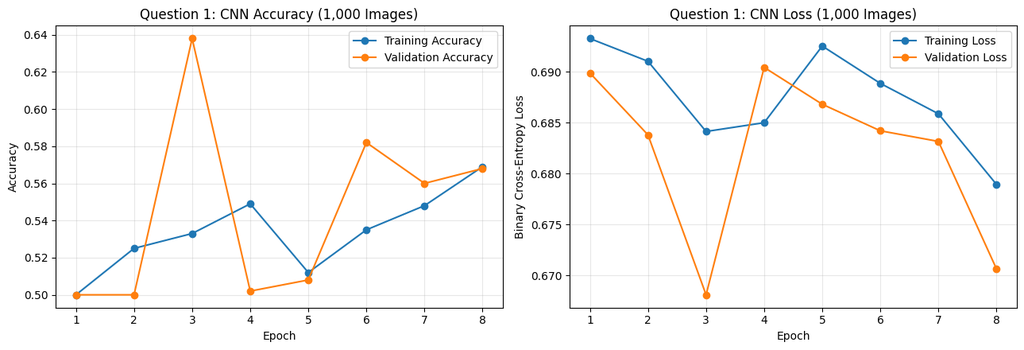

```python
# ============================================================
# AML Assignment 2 - Step 13: Question 1 Training Graphs
# ============================================================

# Retrieve the training history
AML_Q1_HISTORY = AML_HISTORY_SCRATCH_1000.history

AML_Q1_EPOCHS = range(1, len(AML_Q1_HISTORY["loss"]) + 1)

# Create side-by-side learning curves
fig, axes = plt.subplots(1, 2, figsize=(13, 4.5))

# Graph 1: Training and validation accuracy
axes[0].plot(
    AML_Q1_EPOCHS,
    AML_Q1_HISTORY["accuracy"],
    marker="o",
    label="Training Accuracy"
)

axes[0].plot(
    AML_Q1_EPOCHS,
    AML_Q1_HISTORY["val_accuracy"],
    marker="o",
    label="Validation Accuracy"
)

axes[0].set_title("Question 1: CNN Accuracy (1,000 Images)")
axes[0].set_xlabel("Epoch")
axes[0].set_ylabel("Accuracy")
axes[0].legend()
axes[0].grid(alpha=0.3)

# Graph 2: Training and validation loss
axes[1].plot(
    AML_Q1_EPOCHS,
    AML_Q1_HISTORY["loss"],
    marker="o",
    label="Training Loss"
)

axes[1].plot(
    AML_Q1_EPOCHS,
    AML_Q1_HISTORY["val_loss"],
    marker="o",
    label="Validation Loss"
)

axes[1].set_title("Question 1: CNN Loss (1,000 Images)")
axes[1].set_xlabel("Epoch")
axes[1].set_ylabel("Binary Cross-Entropy Loss")
axes[1].legend()
axes[1].grid(alpha=0.3)

plt.tight_layout()
plt.show()
```

### 4.5 Interpretation of Training and Validation Graphs

The accuracy and loss graphs show how the CNN performed during its eight training epochs. Training accuracy increased from 50.0% to 56.9%, indicating that the model gradually learned some useful patterns from the training images.

However, validation accuracy fluctuated during training rather than improving consistently. The highest validation accuracy was 63.8% in epoch 3, and validation loss also reached its lowest value at that point. Afterward, validation loss remained higher, so early stopping restored the weights from epoch 3.

The training curves suggest that the model's learning was limited and somewhat unstable. There was no clear evidence of a large, sustained gap between training and validation performance, so the main concern appears to be limited learning rather than severe overfitting.

Overall, the test accuracy of 61.80% provides a useful baseline. In the next experiment, I will increase the training dataset to 3,000 images while keeping the validation and test sets unchanged.

## Question 2: CNN Trained from Scratch Using 3,000 Images

### 5.1 Increasing the Training Dataset

For the second experiment, I increased the training dataset from 1,000 to 3,000 images, including 1,500 cat images and 1,500 dog images.

The purpose of this experiment is to examine whether providing more training examples helps the CNN learn stronger visual features and improve classification accuracy.

To maintain a fair comparison with Question 1, I kept the same CNN architecture, preprocessing approach, validation dataset of 500 images, and test dataset of 500 images. The model will be initialized with new weights and trained independently rather than continuing training from Question 1.

I will compare the training behavior, validation performance, and final test results with the first experiment.

```python
# ============================================================
# AML Assignment 2 - Step 14: Train Scratch CNN (3,000 Images)
# ============================================================

# Prepare the larger training dataset
AML_TRAIN_DATASET_3000 = aml_create_dataset(
    AML_TRAIN_SPLITS[3000],
    shuffle=True
)

# Build a fresh CNN using the same architecture
AML_SCRATCH_MODEL_3000 = aml_build_scratch_cnn()

# Configure early stopping
AML_EARLY_STOPPING_3000 = keras.callbacks.EarlyStopping(
    monitor="val_loss",
    patience=5,
    restore_best_weights=True
)

# Train the CNN with 3,000 images
AML_HISTORY_SCRATCH_3000 = AML_SCRATCH_MODEL_3000.fit(
    AML_TRAIN_DATASET_3000,
    validation_data=AML_VALIDATION_DATASET,
    epochs=30,
    callbacks=[AML_EARLY_STOPPING_3000],
    verbose=1
)

print("\nQuestion 2 CNN training completed!")
print("Epochs completed:", len(AML_HISTORY_SCRATCH_3000.history["loss"]))
```

```
94/94 ━━━━━━━━━━━━━━━━━━━━ 18s 167ms/step - accuracy: 0.5140 - loss: 0.6935 - val_accuracy: 0.5060 - val_loss: 0.6924
94/94 ━━━━━━━━━━━━━━━━━━━━ 16s 165ms/step - accuracy: 0.5403 - loss: 0.6881 - val_accuracy: 0.5060 - val_loss: 0.6881
94/94 ━━━━━━━━━━━━━━━━━━━━ 15s 159ms/step - accuracy: 0.5683 - loss: 0.6815 - val_accuracy: 0.5620 - val_loss: 0.6794
94/94 ━━━━━━━━━━━━━━━━━━━━ 15s 158ms/step - accuracy: 0.5713 - loss: 0.6752 - val_accuracy: 0.5660 - val_loss: 0.6722
94/94 ━━━━━━━━━━━━━━━━━━━━ 15s 160ms/step - accuracy: 0.5903 - loss: 0.6689 - val_accuracy: 0.5760 - val_loss: 0.6645
94/94 ━━━━━━━━━━━━━━━━━━━━ 15s 158ms/step - accuracy: 0.5920 - loss: 0.6651 - val_accuracy: 0.6040 - val_loss: 0.6629
94/94 ━━━━━━━━━━━━━━━━━━━━ 15s 159ms/step - accuracy: 0.6023 - loss: 0.6569 - val_accuracy: 0.6180 - val_loss: 0.6563
94/94 ━━━━━━━━━━━━━━━━━━━━ 15s 157ms/step - accuracy: 0.5947 - loss: 0.6573 - val_accuracy: 0.6000 - val_loss: 0.6482
94/94 ━━━━━━━━━━━━━━━━━━━━ 15s 158ms/step - accuracy: 0.6013 - loss: 0.6556 - val_accuracy: 0.6320 - val_loss: 0.6474
94/94 ━━━━━━━━━━━━━━━━━━━━ 20s 157ms/step - accuracy: 0.6197 - loss: 0.6463 - val_accuracy: 0.5680 - val_loss: 0.6824
94/94 ━━━━━━━━━━━━━━━━━━━━ 15s 159ms/step - accuracy: 0.6023 - loss: 0.6531 - val_accuracy: 0.5740 - val_loss: 0.6525
94/94 ━━━━━━━━━━━━━━━━━━━━ 21s 160ms/step - accuracy: 0.6307 - loss: 0.6433 - val_accuracy: 0.6080 - val_loss: 0.6429
94/94 ━━━━━━━━━━━━━━━━━━━━ 15s 157ms/step - accuracy: 0.6270 - loss: 0.6379 - val_accuracy: 0.6300 - val_loss: 0.6376
94/94 ━━━━━━━━━━━━━━━━━━━━ 21s 158ms/step - accuracy: 0.6337 - loss: 0.6334 - val_accuracy: 0.6180 - val_loss: 0.6427
94/94 ━━━━━━━━━━━━━━━━━━━━ 16s 167ms/step - accuracy: 0.6197 - loss: 0.6397 - val_accuracy: 0.6380 - val_loss: 0.6301
94/94 ━━━━━━━━━━━━━━━━━━━━ 15s 164ms/step - accuracy: 0.6450 - loss: 0.6234 - val_accuracy: 0.6360 - val_loss: 0.6232
94/94 ━━━━━━━━━━━━━━━━━━━━ 15s 158ms/step - accuracy: 0.6607 - loss: 0.6161 - val_accuracy: 0.6640 - val_loss: 0.6125
94/94 ━━━━━━━━━━━━━━━━━━━━ 20s 157ms/step - accuracy: 0.6507 - loss: 0.6168 - val_accuracy: 0.6340 - val_loss: 0.6158
94/94 ━━━━━━━━━━━━━━━━━━━━ 16s 167ms/step - accuracy: 0.6747 - loss: 0.5991 - val_accuracy: 0.6520 - val_loss: 0.6266
94/94 ━━━━━━━━━━━━━━━━━━━━ 16s 167ms/step - accuracy: 0.6717 - loss: 0.6065 - val_accuracy: 0.6720 - val_loss: 0.6040
94/94 ━━━━━━━━━━━━━━━━━━━━ 15s 158ms/step - accuracy: 0.6780 - loss: 0.6021 - val_accuracy: 0.6860 - val_loss: 0.6001
94/94 ━━━━━━━━━━━━━━━━━━━━ 20s 159ms/step - accuracy: 0.6810 - loss: 0.5934 - val_accuracy: 0.6720 - val_loss: 0.5934
94/94 ━━━━━━━━━━━━━━━━━━━━ 15s 159ms/step - accuracy: 0.6890 - loss: 0.5872 - val_accuracy: 0.7020 - val_loss: 0.5853
94/94 ━━━━━━━━━━━━━━━━━━━━ 20s 157ms/step - accuracy: 0.6843 - loss: 0.5879 - val_accuracy: 0.6940 - val_loss: 0.5827
94/94 ━━━━━━━━━━━━━━━━━━━━ 21s 158ms/step - accuracy: 0.6980 - loss: 0.5754 - val_accuracy: 0.6800 - val_loss: 0.5898
94/94 ━━━━━━━━━━━━━━━━━━━━ 15s 159ms/step - accuracy: 0.6980 - loss: 0.5799 - val_accuracy: 0.7040 - val_loss: 0.5757
94/94 ━━━━━━━━━━━━━━━━━━━━ 20s 158ms/step - accuracy: 0.7003 - loss: 0.5767 - val_accuracy: 0.7000 - val_loss: 0.5825
94/94 ━━━━━━━━━━━━━━━━━━━━ 15s 157ms/step - accuracy: 0.6970 - loss: 0.5714 - val_accuracy: 0.7020 - val_loss: 0.5842
94/94 ━━━━━━━━━━━━━━━━━━━━ 21s 157ms/step - accuracy: 0.7113 - loss: 0.5669 - val_accuracy: 0.6840 - val_loss: 0.5790
94/94 ━━━━━━━━━━━━━━━━━━━━ 16s 172ms/step - accuracy: 0.7063 - loss: 0.5614 - val_accuracy: 0.7180 - val_loss: 0.5701

Question 2 CNN training completed!
Epochs completed: 30
```

### 5.2 Interpretation of CNN Training with 3,000 Images

The second CNN was trained using 3,000 images and completed all 30 epochs. Training accuracy increased from 51.40% in the first epoch to 70.63% in the final epoch. Validation accuracy also improved, reaching 71.80% by epoch 30.

Compared with the first experiment, the larger training dataset produced a stronger learning trend. Validation loss decreased from 0.6924 to 0.5701, suggesting that the model became more effective at distinguishing between cat and dog images.

Although validation accuracy fluctuated during some epochs, the overall trend was positive. The training and validation accuracy values were also relatively close at the end, providing no clear evidence of severe overfitting.

Early stopping did not activate because the model continued improving its validation loss through the final epoch. These findings suggest that increasing the training dataset helped the CNN learn more useful visual patterns. However, the final comparison must be based on performance on the separate test dataset.

```python
# ============================================================
# AML Assignment 2 - Step 15: Evaluate Scratch CNN (3,000)
# ============================================================

# Evaluate the second CNN on the fixed test dataset
AML_TEST_LOSS_SCRATCH_3000, AML_TEST_ACC_SCRATCH_3000 = (
    AML_SCRATCH_MODEL_3000.evaluate(
        AML_TEST_DATASET,
        verbose=0
    )
)

# Save the results for the final comparison table
AML_EXPERIMENT_RESULTS.append({
    "Model": "Scratch CNN",
    "Training Images": 3000,
    "Test Accuracy": AML_TEST_ACC_SCRATCH_3000,
    "Test Loss": AML_TEST_LOSS_SCRATCH_3000
})

# Display the Question 2 results
print("QUESTION 2 - TEST RESULTS")
print(f"Test accuracy: {AML_TEST_ACC_SCRATCH_3000 * 100:.2f}%")
print(f"Test loss: {AML_TEST_LOSS_SCRATCH_3000:.4f}")

# Compare Question 1 and Question 2
AML_ACCURACY_IMPROVEMENT = (
    AML_TEST_ACC_SCRATCH_3000 - AML_TEST_ACC_SCRATCH_1000
) * 100

print(f"\nAccuracy change from Question 1: {AML_ACCURACY_IMPROVEMENT:+.2f} percentage points")
```

```
QUESTION 2 - TEST RESULTS
Test accuracy: 72.00%
Test loss: 0.5575

Accuracy change from Question 1: +10.20 percentage points
```

### 5.3 Interpretation of Test Performance

The CNN trained with 3,000 images achieved a test accuracy of 72.00% and a test loss of 0.5575. This means the model correctly classified 360 out of 500 unseen test images.

Compared with Question 1, where the CNN achieved 61.80% test accuracy, the second model improved by 10.20 percentage points. The test loss also decreased from 0.6696 to 0.5575, indicating that the second model made more accurate predictions overall.

This improvement suggests that increasing the number of training images helped the CNN learn more useful visual features and generalize better to unseen data. Since the architecture, validation set, and test set remained unchanged, the results provide evidence that the larger training dataset was beneficial in this experiment.

However, an accuracy of 72.00% still leaves room for improvement. In Question 3, I will increase the training dataset to 6,000 images to investigate whether additional examples can further improve classification performance.

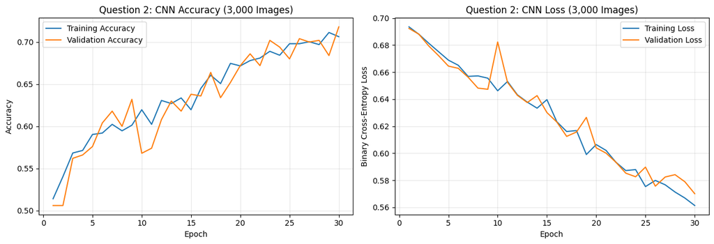

```python
# ============================================================
# AML Assignment 2 - Step 16: Question 2 Training Graphs
# ============================================================

# Retrieve training history for the 3,000-image CNN
AML_Q2_HISTORY = AML_HISTORY_SCRATCH_3000.history

AML_Q2_EPOCHS = range(1, len(AML_Q2_HISTORY["loss"]) + 1)

# Create accuracy and loss graphs
fig, axes = plt.subplots(1, 2, figsize=(13, 4.5))

# Graph 1: Accuracy
axes[0].plot(
    AML_Q2_EPOCHS,
    AML_Q2_HISTORY["accuracy"],
    label="Training Accuracy"
)

axes[0].plot(
    AML_Q2_EPOCHS,
    AML_Q2_HISTORY["val_accuracy"],
    label="Validation Accuracy"
)

axes[0].set_title("Question 2: CNN Accuracy (3,000 Images)")
axes[0].set_xlabel("Epoch")
axes[0].set_ylabel("Accuracy")
axes[0].legend()
axes[0].grid(alpha=0.3)

# Graph 2: Loss
axes[1].plot(
    AML_Q2_EPOCHS,
    AML_Q2_HISTORY["loss"],
    label="Training Loss"
)

axes[1].plot(
    AML_Q2_EPOCHS,
    AML_Q2_HISTORY["val_loss"],
    label="Validation Loss"
)

axes[1].set_title("Question 2: CNN Loss (3,000 Images)")
axes[1].set_xlabel("Epoch")
axes[1].set_ylabel("Binary Cross-Entropy Loss")
axes[1].legend()
axes[1].grid(alpha=0.3)

plt.tight_layout()
plt.show()
```

### 5.4 Interpretation of Training and Validation Graphs

The training graphs for Question 2 show an overall improvement in the CNN's performance across 30 epochs. Training accuracy increased from 51.40% to 70.63%, while validation accuracy increased from 50.60% to 71.80%.

The loss graph also shows an encouraging trend. Training loss decreased from 0.6935 to 0.5614, and validation loss decreased from 0.6924 to 0.5701. Although the curves fluctuated during some epochs, the overall direction suggests that the model continued learning throughout the experiment.

Training and validation performance remained relatively close, suggesting that severe overfitting was not evident in these results. Unlike Question 1, early stopping did not activate because validation loss reached its lowest value at the final epoch.

The test accuracy of 72.00%, compared with 61.80% in Question 1, supports the conclusion that increasing the training dataset improved classification performance in this experiment.

## Question 3: CNN Trained from Scratch Using 6,000 Images

### 6.1 Experiment Design

For the third experiment, I increased the training dataset to 6,000 images, consisting of 3,000 cat images and 3,000 dog images. This is twice the training size used in Question 2 and six times the size used in Question 1.

The purpose of this experiment is to determine whether additional training examples can help the CNN learn more reliable visual patterns and improve classification accuracy.

To make the comparison consistent, I will use the same CNN architecture, preprocessing method, optimizer, validation dataset, and test dataset as in the previous experiments. I will also initialize a new CNN rather than continuing training from Question 2.

After training, I will evaluate the model using the fixed test dataset and compare its results with the 1,000-image and 3,000-image experiments.

```python
# ============================================================
# AML Assignment 2 - Step 17: Train Scratch CNN (6,000 Images)
# ============================================================

# Prepare the balanced 6,000-image training dataset
AML_TRAIN_DATASET_6000 = aml_create_dataset(
    AML_TRAIN_SPLITS[6000],
    shuffle=True
)

# Build a new CNN with the same architecture
AML_SCRATCH_MODEL_6000 = aml_build_scratch_cnn()

# Configure early stopping to monitor validation loss
AML_EARLY_STOPPING_6000 = keras.callbacks.EarlyStopping(
    monitor="val_loss",
    patience=5,
    restore_best_weights=True
)

# Train the CNN using 6,000 images
AML_HISTORY_SCRATCH_6000 = AML_SCRATCH_MODEL_6000.fit(
    AML_TRAIN_DATASET_6000,
    validation_data=AML_VALIDATION_DATASET,
    epochs=30,
    callbacks=[AML_EARLY_STOPPING_6000],
    verbose=1
)

print("\nQuestion 3 CNN training completed!")
print("Epochs completed:", len(AML_HISTORY_SCRATCH_6000.history["loss"]))
```

```
188/188 ━━━━━━━━━━━━━━━━━━━━ 30s 151ms/step - accuracy: 0.5165 - loss: 0.6921 - val_accuracy: 0.5540 - val_loss: 0.6866
188/188 ━━━━━━━━━━━━━━━━━━━━ 28s 147ms/step - accuracy: 0.5510 - loss: 0.6862 - val_accuracy: 0.5260 - val_loss: 0.6834
188/188 ━━━━━━━━━━━━━━━━━━━━ 42s 153ms/step - accuracy: 0.5718 - loss: 0.6752 - val_accuracy: 0.5920 - val_loss: 0.6675
188/188 ━━━━━━━━━━━━━━━━━━━━ 40s 147ms/step - accuracy: 0.5975 - loss: 0.6661 - val_accuracy: 0.6220 - val_loss: 0.6461
188/188 ━━━━━━━━━━━━━━━━━━━━ 28s 151ms/step - accuracy: 0.5998 - loss: 0.6609 - val_accuracy: 0.6140 - val_loss: 0.6350
188/188 ━━━━━━━━━━━━━━━━━━━━ 40s 148ms/step - accuracy: 0.6150 - loss: 0.6563 - val_accuracy: 0.6800 - val_loss: 0.6215
188/188 ━━━━━━━━━━━━━━━━━━━━ 41s 147ms/step - accuracy: 0.6345 - loss: 0.6437 - val_accuracy: 0.6360 - val_loss: 0.6203
188/188 ━━━━━━━━━━━━━━━━━━━━ 42s 151ms/step - accuracy: 0.6400 - loss: 0.6301 - val_accuracy: 0.6760 - val_loss: 0.5962
188/188 ━━━━━━━━━━━━━━━━━━━━ 28s 147ms/step - accuracy: 0.6663 - loss: 0.6168 - val_accuracy: 0.6840 - val_loss: 0.5961
188/188 ━━━━━━━━━━━━━━━━━━━━ 41s 147ms/step - accuracy: 0.6778 - loss: 0.6100 - val_accuracy: 0.6780 - val_loss: 0.6289
188/188 ━━━━━━━━━━━━━━━━━━━━ 28s 147ms/step - accuracy: 0.6812 - loss: 0.5999 - val_accuracy: 0.6920 - val_loss: 0.5802
188/188 ━━━━━━━━━━━━━━━━━━━━ 41s 147ms/step - accuracy: 0.6902 - loss: 0.5901 - val_accuracy: 0.7140 - val_loss: 0.5580
188/188 ━━━━━━━━━━━━━━━━━━━━ 28s 147ms/step - accuracy: 0.6932 - loss: 0.5858 - val_accuracy: 0.6880 - val_loss: 0.5699
188/188 ━━━━━━━━━━━━━━━━━━━━ 28s 147ms/step - accuracy: 0.7007 - loss: 0.5823 - val_accuracy: 0.7220 - val_loss: 0.5608
188/188 ━━━━━━━━━━━━━━━━━━━━ 28s 147ms/step - accuracy: 0.7063 - loss: 0.5728 - val_accuracy: 0.6940 - val_loss: 0.5716
188/188 ━━━━━━━━━━━━━━━━━━━━ 41s 147ms/step - accuracy: 0.7105 - loss: 0.5669 - val_accuracy: 0.7280 - val_loss: 0.5600
188/188 ━━━━━━━━━━━━━━━━━━━━ 42s 153ms/step - accuracy: 0.7137 - loss: 0.5638 - val_accuracy: 0.7200 - val_loss: 0.5525
188/188 ━━━━━━━━━━━━━━━━━━━━ 40s 147ms/step - accuracy: 0.7237 - loss: 0.5542 - val_accuracy: 0.7200 - val_loss: 0.5682
188/188 ━━━━━━━━━━━━━━━━━━━━ 41s 149ms/step - accuracy: 0.7250 - loss: 0.5523 - val_accuracy: 0.7240 - val_loss: 0.5479
188/188 ━━━━━━━━━━━━━━━━━━━━ 28s 150ms/step - accuracy: 0.7293 - loss: 0.5452 - val_accuracy: 0.6920 - val_loss: 0.6004
188/188 ━━━━━━━━━━━━━━━━━━━━ 28s 147ms/step - accuracy: 0.7325 - loss: 0.5436 - val_accuracy: 0.7100 - val_loss: 0.5730
188/188 ━━━━━━━━━━━━━━━━━━━━ 28s 148ms/step - accuracy: 0.7387 - loss: 0.5343 - val_accuracy: 0.7140 - val_loss: 0.5533
188/188 ━━━━━━━━━━━━━━━━━━━━ 28s 147ms/step - accuracy: 0.7372 - loss: 0.5421 - val_accuracy: 0.7340 - val_loss: 0.5280
188/188 ━━━━━━━━━━━━━━━━━━━━ 41s 147ms/step - accuracy: 0.7368 - loss: 0.5273 - val_accuracy: 0.7260 - val_loss: 0.5631
188/188 ━━━━━━━━━━━━━━━━━━━━ 41s 147ms/step - accuracy: 0.7507 - loss: 0.5208 - val_accuracy: 0.7280 - val_loss: 0.5498
188/188 ━━━━━━━━━━━━━━━━━━━━ 41s 147ms/step - accuracy: 0.7460 - loss: 0.5187 - val_accuracy: 0.7080 - val_loss: 0.5686
188/188 ━━━━━━━━━━━━━━━━━━━━ 41s 148ms/step - accuracy: 0.7450 - loss: 0.5192 - val_accuracy: 0.7260 - val_loss: 0.5580
188/188 ━━━━━━━━━━━━━━━━━━━━ 42s 152ms/step - accuracy: 0.7473 - loss: 0.5160 - val_accuracy: 0.7420 - val_loss: 0.5241
188/188 ━━━━━━━━━━━━━━━━━━━━ 28s 147ms/step - accuracy: 0.7588 - loss: 0.5056 - val_accuracy: 0.7380 - val_loss: 0.5182
188/188 ━━━━━━━━━━━━━━━━━━━━ 28s 148ms/step - accuracy: 0.7505 - loss: 0.5095 - val_accuracy: 0.7300 - val_loss: 0.5541

Question 3 CNN training completed!
Epochs completed: 30
```

### 6.2 Interpretation of CNN Training with 6,000 Images

The third CNN was trained using 6,000 images and completed all 30 epochs. Training accuracy increased from 51.65% in the first epoch to 75.05% in the final epoch. Validation accuracy also improved overall, reaching 73.00% in the final epoch.

The highest validation accuracy was 74.20% at epoch 28, while the lowest validation loss was 0.5182 at epoch 29. Since early stopping monitored validation loss, the model restored the weights from epoch 29.

Compared with the earlier experiments, the 6,000-image model achieved a higher final training accuracy and a lower minimum validation loss. This suggests that providing additional training images helped the CNN develop stronger visual features.

Although validation performance fluctuated between epochs, the training and validation accuracy values remained relatively close. There was no clear evidence of severe overfitting, although the fluctuations show that the model's performance was not completely stable.

The next step is to evaluate the model using the same 500 test images used in Questions 1 and 2. This will allow me to determine whether the larger training dataset improved performance on unseen images.

```python
# ============================================================
# AML Assignment 2 - Step 18: Evaluate Scratch CNN (6,000)
# ============================================================

# Evaluate the CNN on the fixed, unseen test dataset
AML_TEST_LOSS_SCRATCH_6000, AML_TEST_ACC_SCRATCH_6000 = (
    AML_SCRATCH_MODEL_6000.evaluate(
        AML_TEST_DATASET,
        verbose=0
    )
)

# Store the result for the final comparison
AML_EXPERIMENT_RESULTS.append({
    "Model": "Scratch CNN",
    "Training Images": 6000,
    "Test Accuracy": AML_TEST_ACC_SCRATCH_6000,
    "Test Loss": AML_TEST_LOSS_SCRATCH_6000
})

# Calculate the improvement over Questions 1 and 2
AML_Q3_CHANGE_FROM_Q1 = (
    AML_TEST_ACC_SCRATCH_6000 - AML_TEST_ACC_SCRATCH_1000
) * 100

AML_Q3_CHANGE_FROM_Q2 = (
    AML_TEST_ACC_SCRATCH_6000 - AML_TEST_ACC_SCRATCH_3000
) * 100

# Display the results
print("QUESTION 3 - TEST RESULTS")
print(f"Test accuracy: {AML_TEST_ACC_SCRATCH_6000 * 100:.2f}%")
print(f"Test loss: {AML_TEST_LOSS_SCRATCH_6000:.4f}")

print(f"\nAccuracy change from Question 1: {AML_Q3_CHANGE_FROM_Q1:+.2f} percentage points")
print(f"Accuracy change from Question 2: {AML_Q3_CHANGE_FROM_Q2:+.2f} percentage points")
```

```
QUESTION 3 - TEST RESULTS
Test accuracy: 75.00%
Test loss: 0.5169

Accuracy change from Question 1: +13.20 percentage points
Accuracy change from Question 2: +3.00 percentage points
```

### 6.3 Interpretation of Test Performance

The CNN trained with 6,000 images achieved a test accuracy of 75.00% and a test loss of 0.5169. This means the model correctly classified 375 out of 500 unseen test images.

Compared with Question 1, test accuracy increased by 13.20 percentage points, from 61.80% to 75.00%. Compared with Question 2, accuracy increased by another 3.00 percentage points, from 72.00% to 75.00%.

The test loss also decreased across the experiments, suggesting that the CNN became more effective at making predictions as the training dataset increased.

These results show that the 6,000-image CNN performed best among the three models trained from scratch. However, the improvement from 3,000 to 6,000 images was smaller than the improvement from 1,000 to 3,000 images. This suggests that adding more training data continued to help, although the additional benefit became smaller in these experiments.

Overall, Question 3 demonstrates that increasing the training sample size improved classification performance while maintaining the same CNN architecture and evaluation datasets.

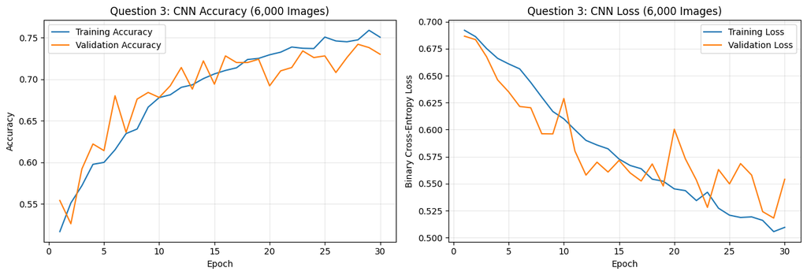

```python
# ============================================================
# AML Assignment 2 - Step 19: Question 3 Training Graphs
# ============================================================

# Retrieve the training history for the 6,000-image CNN
AML_Q3_HISTORY = AML_HISTORY_SCRATCH_6000.history

AML_Q3_EPOCHS = range(1, len(AML_Q3_HISTORY["loss"]) + 1)

# Create the accuracy and loss graphs
fig, axes = plt.subplots(1, 2, figsize=(13, 4.5))

# Graph 1: Training and validation accuracy
axes[0].plot(
    AML_Q3_EPOCHS,
    AML_Q3_HISTORY["accuracy"],
    label="Training Accuracy"
)

axes[0].plot(
    AML_Q3_EPOCHS,
    AML_Q3_HISTORY["val_accuracy"],
    label="Validation Accuracy"
)

axes[0].set_title("Question 3: CNN Accuracy (6,000 Images)")
axes[0].set_xlabel("Epoch")
axes[0].set_ylabel("Accuracy")
axes[0].legend()
axes[0].grid(alpha=0.3)

# Graph 2: Training and validation loss
axes[1].plot(
    AML_Q3_EPOCHS,
    AML_Q3_HISTORY["loss"],
    label="Training Loss"
)

axes[1].plot(
    AML_Q3_EPOCHS,
    AML_Q3_HISTORY["val_loss"],
    label="Validation Loss"
)

axes[1].set_title("Question 3: CNN Loss (6,000 Images)")
axes[1].set_xlabel("Epoch")
axes[1].set_ylabel("Binary Cross-Entropy Loss")
axes[1].legend()
axes[1].grid(alpha=0.3)

plt.tight_layout()
plt.show()
```

### 6.4 Interpretation of Training and Validation Graphs

The training and validation graphs for Question 3 show an overall improvement in model performance across 30 epochs. Training accuracy increased from 51.65% to 75.05%, while validation accuracy increased from 55.40% to 73.00%.

Both training and validation loss generally decreased as training progressed. Although validation loss fluctuated during some epochs, it reached its lowest value of 0.5182 at epoch 29. The model restored the weights from this epoch because early stopping was configured to retain the best validation-loss performance.

The training and validation accuracy curves remained relatively close, suggesting that the model did not experience severe overfitting. The fluctuations in validation performance indicate that some uncertainty remained, but the overall learning trend was positive.

The final test accuracy of 75.00% was higher than the results obtained using 1,000 and 3,000 training images. This supports the finding that increasing the training dataset improved the CNN's ability to classify unseen images in these experiments.

## 7. Comparison of CNN Models Trained from Scratch

### 7.1 Effect of Training Dataset Size

To understand the relationship between training dataset size and CNN performance, I compared the three models trained from scratch using 1,000, 3,000, and 6,000 images.

All three experiments used the same CNN architecture, preprocessing approach, validation dataset, and test dataset. This allowed me to investigate how increasing the number of training examples affected classification performance.

The following table and graph summarize the test accuracy and test loss obtained from the three experiments.

```
COMPARISON OF SCRATCH CNN EXPERIMENTS
```

|  | Model | Training Images | Test Accuracy (%) | Test Loss |
| --- | --- | --- | --- | --- |
| 0 | Scratch CNN | 1000 | 61.8 | 0.6696 |
| 1 | Scratch CNN | 3000 | 72.0 | 0.5575 |
| 2 | Scratch CNN | 6000 | 75.0 | 0.5169 |

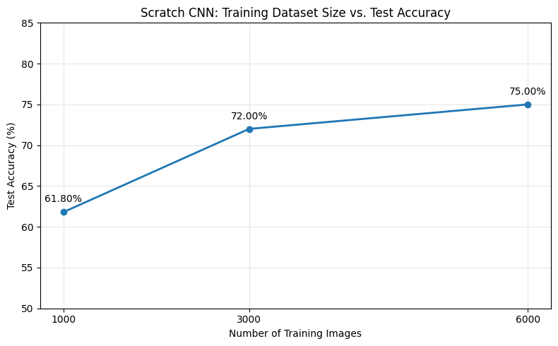

```python
# ============================================================
# AML Assignment 2 - Step 20: Compare Scratch CNN Experiments
# ============================================================

# Create a table from the three completed experiments
AML_SCRATCH_COMPARISON = pd.DataFrame(
    AML_EXPERIMENT_RESULTS
).sort_values("Training Images").copy()

# Convert accuracy into percentages for easier interpretation
AML_SCRATCH_COMPARISON["Test Accuracy (%)"] = (
    AML_SCRATCH_COMPARISON["Test Accuracy"] * 100
)

# Display a clean summary table
print("COMPARISON OF SCRATCH CNN EXPERIMENTS")

display(
    AML_SCRATCH_COMPARISON[
        ["Model", "Training Images", "Test Accuracy (%)", "Test Loss"]
    ].round(4)
)

# Plot test accuracy against training dataset size
plt.figure(figsize=(8, 5))

plt.plot(
    AML_SCRATCH_COMPARISON["Training Images"],
    AML_SCRATCH_COMPARISON["Test Accuracy (%)"],
    marker="o",
    linewidth=2
)

# Add accuracy labels above each point
for _, experiment in AML_SCRATCH_COMPARISON.iterrows():
    plt.annotate(
        f'{experiment["Test Accuracy (%)"]:.2f}%',
        (
            experiment["Training Images"],
            experiment["Test Accuracy (%)"]
        ),
        textcoords="offset points",
        xytext=(0, 10),
        ha="center"
    )

plt.title("Scratch CNN: Training Dataset Size vs. Test Accuracy")
plt.xlabel("Number of Training Images")
plt.ylabel("Test Accuracy (%)")
plt.xticks([1000, 3000, 6000])
plt.ylim(50, 85)
plt.grid(alpha=0.3)
plt.tight_layout()
plt.show()
```

### 7.2 Interpretation of the Scratch CNN Comparison

The comparison of the three CNN experiments shows that increasing the training dataset improved classification performance on the fixed test set.

With 1,000 training images, the CNN achieved 61.80% test accuracy. Increasing the dataset to 3,000 images improved accuracy to 72.00%, an increase of 10.20 percentage points. Using 6,000 images increased accuracy further to 75.00%, an additional improvement of 3.00 percentage points.

Test loss also decreased consistently, from 0.6696 with 1,000 images to 0.5575 with 3,000 images and 0.5169 with 6,000 images.

These results suggest that larger training datasets helped the CNN learn more useful visual features. However, the improvement between 3,000 and 6,000 images was smaller than the improvement between 1,000 and 3,000 images, suggesting diminishing gains within the training sizes tested.

Overall, the 6,000-image CNN produced the best test performance among the three scratch models. The next stage of the assignment will investigate whether a pretrained CNN can achieve better results using the same training dataset sizes.

## Question 4: Image Classification Using a Pretrained CNN

### 8.1 Transfer Learning with MobileNetV2

For Question 4, I selected MobileNetV2, a convolutional neural network pretrained on the ImageNet dataset. Unlike the CNN developed from scratch in Questions 1–3, MobileNetV2 has already learned general visual features from a large image dataset.

Transfer learning allows these previously learned features to be reused for a new classification task. In this assignment, I will use MobileNetV2 as a feature extractor and add a new classification layer to distinguish between cats and dogs.

I will repeat the experiments using 1,000, 3,000, and 6,000 training images while keeping the same fixed validation and test datasets. The pretrained feature-extraction layers will initially remain frozen, and only the new classification layers will be trained.

The purpose of these experiments is to compare the effectiveness of transfer learning with training a CNN entirely from scratch, particularly when the available training dataset is small.

```python
# ============================================================
# AML Assignment 2 - Step 21: Pretrained MobileNetV2 Architecture
# ============================================================

# Create a reusable pretrained CNN model
def aml_build_pretrained_cnn():

    # Load MobileNetV2 with pretrained ImageNet weights
    aml_feature_extractor = keras.applications.MobileNetV2(
        input_shape=(150, 150, 3),
        include_top=False,
        weights="imagenet"
    )

    # Freeze pretrained layers to preserve learned features
    aml_feature_extractor.trainable = False

    # Define the model input
    aml_image_input = keras.Input(shape=(150, 150, 3))

    # Apply image augmentation during training
    aml_augmented_images = layers.RandomFlip(
        "horizontal",
        seed=AML_SEED
    )(aml_image_input)

    # MobileNetV2 expects pixels in the range -1 to 1
    aml_processed_images = layers.Rescaling(
        scale=1.0 / 127.5,
        offset=-1
    )(aml_augmented_images)

    # Extract visual features without updating pretrained weights
    aml_image_features = aml_feature_extractor(
        aml_processed_images,
        training=False
    )

    # Build a new binary classification head
    aml_pooled_features = layers.GlobalAveragePooling2D()(
        aml_image_features
    )

    aml_regularized_features = layers.Dropout(0.30)(
        aml_pooled_features
    )

    aml_classification_output = layers.Dense(
        1,
        activation="sigmoid"
    )(aml_regularized_features)

    # Assemble the pretrained classification model
    aml_transfer_model = keras.Model(
        inputs=aml_image_input,
        outputs=aml_classification_output,
        name="AML_Pretrained_MobileNetV2"
    )

    # Compile the model
    aml_transfer_model.compile(
        optimizer=keras.optimizers.Adam(learning_rate=0.0001),
        loss="binary_crossentropy",
        metrics=["accuracy"]
    )

    return aml_transfer_model


# Build the first pretrained model
AML_PRETRAINED_MODEL_1000 = aml_build_pretrained_cnn()

# Display the architecture and parameter counts
AML_PRETRAINED_MODEL_1000.summary()
```

```
Downloading data from https://storage.googleapis.com/tensorflow/keras-applications/mobilenet_v2/mobilenet_v2_weights_tf_dim_ordering_tf_kernels_1.0_224_no_top.h5
9406464/9406464 ━━━━━━━━━━━━━━━━━━━━ 0s 0us/step
```

```
Model: "AML_Pretrained_MobileNetV2"
```

```
┏━━━━━━━━━━━━━━━━━━━━━━━━━━━━━━━━━┳━━━━━━━━━━━━━━━━━━━━━━━━┳━━━━━━━━━━━━━━━┓
┃ Layer (type)                    ┃ Output Shape           ┃       Param # ┃
┡━━━━━━━━━━━━━━━━━━━━━━━━━━━━━━━━━╇━━━━━━━━━━━━━━━━━━━━━━━━╇━━━━━━━━━━━━━━━┩
│ input_layer_4 (InputLayer)      │ (None, 150, 150, 3)    │             0 │
├─────────────────────────────────┼────────────────────────┼───────────────┤
│ random_flip_3 (RandomFlip)      │ (None, 150, 150, 3)    │             0 │
├─────────────────────────────────┼────────────────────────┼───────────────┤
│ rescaling_3 (Rescaling)         │ (None, 150, 150, 3)    │             0 │
├─────────────────────────────────┼────────────────────────┼───────────────┤
│ mobilenetv2_1.00_224            │ (None, 5, 5, 1280)     │     2,257,984 │
│ (Functional)                    │                        │               │
├─────────────────────────────────┼────────────────────────┼───────────────┤
│ global_average_pooling2d_3      │ (None, 1280)           │             0 │
│ (GlobalAveragePooling2D)        │                        │               │
├─────────────────────────────────┼────────────────────────┼───────────────┤
│ dropout_3 (Dropout)             │ (None, 1280)           │             0 │
├─────────────────────────────────┼────────────────────────┼───────────────┤
│ dense_6 (Dense)                 │ (None, 1)              │         1,281 │
└─────────────────────────────────┴────────────────────────┴───────────────┘
```

```
 Total params: 2,259,265 (8.62 MB)
```

```
 Trainable params: 1,281 (5.00 KB)
```

```
 Non-trainable params: 2,257,984 (8.61 MB)
```

### 8.2 Interpretation of the Pretrained Model Architecture

The pretrained MobileNetV2 model was successfully initialized using ImageNet weights. The complete model contains 2,259,265 parameters, of which 2,257,984 are non-trainable and 1,281 are trainable.

The pretrained feature-extraction layers were frozen so that the visual features learned from ImageNet would be preserved during training. A new classification layer was added to adapt the network to the cat-versus-dog classification task.

The model also includes global average pooling and dropout to support classification and reduce overfitting. Image preprocessing converts pixel values to the range expected by MobileNetV2.

Compared with the CNN trained from scratch, this model has substantially fewer trainable parameters because most of its visual features have already been learned. This may help the model achieve stronger performance, especially when training data is limited.

The next experiment will train the new classification layer using 1,000 images and evaluate its performance on the fixed validation and test datasets.

```python
# ============================================================
# AML Assignment 2 - Step 22: Train MobileNetV2 (1,000 Images)
# ============================================================

# Use the same training dataset as Question 1
AML_PRETRAINED_TRAIN_1000 = aml_create_dataset(
    AML_TRAIN_SPLITS[1000],
    shuffle=True
)

# Stop training if validation loss stops improving
AML_PRETRAINED_STOPPING_1000 = keras.callbacks.EarlyStopping(
    monitor="val_loss",
    patience=5,
    restore_best_weights=True
)

# Train the pretrained CNN classification layer
AML_HISTORY_PRETRAINED_1000 = AML_PRETRAINED_MODEL_1000.fit(
    AML_PRETRAINED_TRAIN_1000,
    validation_data=AML_VALIDATION_DATASET,
    epochs=20,
    callbacks=[AML_PRETRAINED_STOPPING_1000],
    verbose=1
)

print("\nPretrained MobileNetV2 training completed!")
print(
    "Epochs completed:",
    len(AML_HISTORY_PRETRAINED_1000.history["loss"])
)
```

```
32/32 ━━━━━━━━━━━━━━━━━━━━ 32s 610ms/step - accuracy: 0.6370 - loss: 0.7440 - val_accuracy: 0.7500 - val_loss: 0.5355
32/32 ━━━━━━━━━━━━━━━━━━━━ 6s 192ms/step - accuracy: 0.7440 - loss: 0.5467 - val_accuracy: 0.8240 - val_loss: 0.4162
32/32 ━━━━━━━━━━━━━━━━━━━━ 10s 194ms/step - accuracy: 0.7880 - loss: 0.4458 - val_accuracy: 0.8580 - val_loss: 0.3404
32/32 ━━━━━━━━━━━━━━━━━━━━ 11s 212ms/step - accuracy: 0.8580 - loss: 0.3512 - val_accuracy: 0.8820 - val_loss: 0.2897
32/32 ━━━━━━━━━━━━━━━━━━━━ 10s 195ms/step - accuracy: 0.8870 - loss: 0.2985 - val_accuracy: 0.8980 - val_loss: 0.2542
32/32 ━━━━━━━━━━━━━━━━━━━━ 6s 193ms/step - accuracy: 0.9000 - loss: 0.2814 - val_accuracy: 0.9080 - val_loss: 0.2295
32/32 ━━━━━━━━━━━━━━━━━━━━ 12s 240ms/step - accuracy: 0.8970 - loss: 0.2610 - val_accuracy: 0.9200 - val_loss: 0.2087
32/32 ━━━━━━━━━━━━━━━━━━━━ 6s 195ms/step - accuracy: 0.9170 - loss: 0.2292 - val_accuracy: 0.9320 - val_loss: 0.1934
32/32 ━━━━━━━━━━━━━━━━━━━━ 10s 191ms/step - accuracy: 0.9280 - loss: 0.2033 - val_accuracy: 0.9300 - val_loss: 0.1816
32/32 ━━━━━━━━━━━━━━━━━━━━ 6s 194ms/step - accuracy: 0.9230 - loss: 0.1993 - val_accuracy: 0.9320 - val_loss: 0.1722
32/32 ━━━━━━━━━━━━━━━━━━━━ 10s 195ms/step - accuracy: 0.9260 - loss: 0.1868 - val_accuracy: 0.9360 - val_loss: 0.1636
32/32 ━━━━━━━━━━━━━━━━━━━━ 6s 191ms/step - accuracy: 0.9350 - loss: 0.1763 - val_accuracy: 0.9360 - val_loss: 0.1569
32/32 ━━━━━━━━━━━━━━━━━━━━ 6s 195ms/step - accuracy: 0.9350 - loss: 0.1718 - val_accuracy: 0.9360 - val_loss: 0.1515
32/32 ━━━━━━━━━━━━━━━━━━━━ 6s 192ms/step - accuracy: 0.9370 - loss: 0.1698 - val_accuracy: 0.9400 - val_loss: 0.1457
32/32 ━━━━━━━━━━━━━━━━━━━━ 6s 190ms/step - accuracy: 0.9400 - loss: 0.1572 - val_accuracy: 0.9440 - val_loss: 0.1407
32/32 ━━━━━━━━━━━━━━━━━━━━ 6s 194ms/step - accuracy: 0.9440 - loss: 0.1574 - val_accuracy: 0.9420 - val_loss: 0.1385
32/32 ━━━━━━━━━━━━━━━━━━━━ 6s 191ms/step - accuracy: 0.9430 - loss: 0.1499 - val_accuracy: 0.9480 - val_loss: 0.1326
32/32 ━━━━━━━━━━━━━━━━━━━━ 6s 195ms/step - accuracy: 0.9460 - loss: 0.1451 - val_accuracy: 0.9500 - val_loss: 0.1294
32/32 ━━━━━━━━━━━━━━━━━━━━ 6s 194ms/step - accuracy: 0.9470 - loss: 0.1381 - val_accuracy: 0.9500 - val_loss: 0.1266
32/32 ━━━━━━━━━━━━━━━━━━━━ 6s 191ms/step - accuracy: 0.9510 - loss: 0.1314 - val_accuracy: 0.9520 - val_loss: 0.1237

Pretrained MobileNetV2 training completed!
Epochs completed: 20
```

### 8.3 Interpretation of Pretrained MobileNetV2 Training with 1,000 Images

The pretrained MobileNetV2 model was trained using 1,000 images and completed all 20 epochs. Training accuracy increased from 63.70% in the first epoch to 95.10% in the final epoch. Validation accuracy also improved significantly, increasing from 75.00% to 95.20%.

Training loss decreased from 0.7440 to 0.1314, while validation loss decreased from 0.5355 to 0.1237. These results show that the model learned to distinguish between cats and dogs effectively during training.

The training and validation accuracy values remained close, suggesting that severe overfitting was not evident in this experiment. Early stopping did not activate because validation loss continued improving through the final epoch.

Compared with the CNN trained from scratch using 1,000 images, MobileNetV2 achieved substantially higher validation accuracy. This suggests that reusing visual features learned from ImageNet is beneficial when the available training dataset is relatively small.

The next step is to evaluate the pretrained model on the separate 500-image test dataset to determine how well it generalizes to unseen images.

```python
# ============================================================
# AML Assignment 2 - Step 23: Evaluate MobileNetV2 (1,000)
# ============================================================

# Evaluate the pretrained model on the fixed test dataset
AML_TEST_LOSS_PRETRAINED_1000, AML_TEST_ACC_PRETRAINED_1000 = (
    AML_PRETRAINED_MODEL_1000.evaluate(
        AML_TEST_DATASET,
        verbose=0
    )
)

# Save the result for the final six-model comparison
AML_EXPERIMENT_RESULTS.append({
    "Model": "Pretrained MobileNetV2",
    "Training Images": 1000,
    "Test Accuracy": AML_TEST_ACC_PRETRAINED_1000,
    "Test Loss": AML_TEST_LOSS_PRETRAINED_1000
})

# Compare pretrained and scratch CNNs at the same training size
AML_TRANSFER_GAIN_1000 = (
    AML_TEST_ACC_PRETRAINED_1000 - AML_TEST_ACC_SCRATCH_1000
) * 100

print("QUESTION 4 - PRETRAINED MODEL (1,000 IMAGES)")
print(f"Test accuracy: {AML_TEST_ACC_PRETRAINED_1000 * 100:.2f}%")
print(f"Test loss: {AML_TEST_LOSS_PRETRAINED_1000:.4f}")

print(
    f"\nAccuracy improvement over scratch CNN: "
    f"{AML_TRANSFER_GAIN_1000:+.2f} percentage points"
)
```

```
QUESTION 4 - PRETRAINED MODEL (1,000 IMAGES)
Test accuracy: 95.40%
Test loss: 0.1244

Accuracy improvement over scratch CNN: +33.60 percentage points
```

### 8.4 Interpretation of Pretrained Model Test Performance

The pretrained MobileNetV2 model achieved a test accuracy of 95.40% and a test loss of 0.1244 using 1,000 training images. This means the model correctly classified 477 out of 500 unseen test images.

In comparison, the CNN trained from scratch using the same 1,000 training images achieved a test accuracy of 61.80%. Therefore, MobileNetV2 improved classification accuracy by 33.60 percentage points.

The pretrained model also achieved a substantially lower test loss, decreasing from 0.6696 for the scratch CNN to 0.1244. This indicates that the pretrained model produced better predictions overall.

The improvement suggests that transfer learning is highly effective for this classification task. Because MobileNetV2 had already learned general visual features from ImageNet, it did not need to learn all image features from the relatively small training dataset.

These results show that the pretrained CNN performed much better than the scratch CNN when both models were trained using 1,000 images. The next experiments will examine whether increasing the training dataset to 3,000 and 6,000 images produces additional improvements.

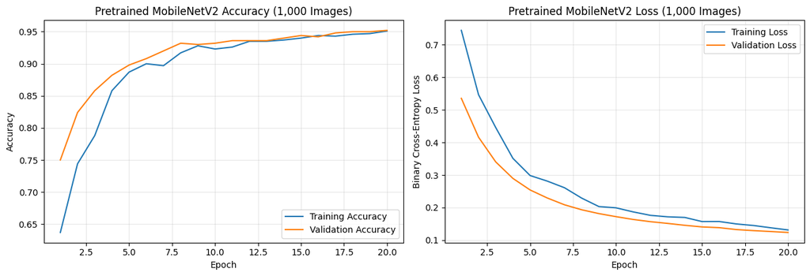

```python
# ============================================================
# AML Assignment 2 - Step 24: Pretrained CNN Training Graphs
# ============================================================

# Retrieve training history for the 1,000-image pretrained CNN
AML_TRANSFER_HISTORY_1000 = AML_HISTORY_PRETRAINED_1000.history

AML_TRANSFER_EPOCHS_1000 = range(
    1,
    len(AML_TRANSFER_HISTORY_1000["loss"]) + 1
)

# Create accuracy and loss graphs
fig, axes = plt.subplots(1, 2, figsize=(13, 4.5))

# Graph 1: Training and validation accuracy
axes[0].plot(
    AML_TRANSFER_EPOCHS_1000,
    AML_TRANSFER_HISTORY_1000["accuracy"],
    label="Training Accuracy"
)

axes[0].plot(
    AML_TRANSFER_EPOCHS_1000,
    AML_TRANSFER_HISTORY_1000["val_accuracy"],
    label="Validation Accuracy"
)

axes[0].set_title("Pretrained MobileNetV2 Accuracy (1,000 Images)")
axes[0].set_xlabel("Epoch")
axes[0].set_ylabel("Accuracy")
axes[0].legend()
axes[0].grid(alpha=0.3)

# Graph 2: Training and validation loss
axes[1].plot(
    AML_TRANSFER_EPOCHS_1000,
    AML_TRANSFER_HISTORY_1000["loss"],
    label="Training Loss"
)

axes[1].plot(
    AML_TRANSFER_EPOCHS_1000,
    AML_TRANSFER_HISTORY_1000["val_loss"],
    label="Validation Loss"
)

axes[1].set_title("Pretrained MobileNetV2 Loss (1,000 Images)")
axes[1].set_xlabel("Epoch")
axes[1].set_ylabel("Binary Cross-Entropy Loss")
axes[1].legend()
axes[1].grid(alpha=0.3)

plt.tight_layout()
plt.show()
```

### 8.5 Interpretation of Pretrained MobileNetV2 Training Graphs

The training and validation graphs show that MobileNetV2 learned effectively using 1,000 training images. Training accuracy increased from 63.70% to 95.10%, while validation accuracy improved from 75.00% to 95.20% over 20 epochs.

The loss curves also showed consistent improvement. Training loss decreased from 0.7440 to 0.1314, and validation loss decreased from 0.5355 to 0.1237. This indicates that the new classification layer became increasingly effective at distinguishing cats from dogs.

Training and validation accuracy remained close during the later epochs, suggesting that severe overfitting was not evident. Validation loss continued decreasing through the final epoch, so early stopping did not activate.

The final test accuracy of 95.40% was substantially higher than the 61.80% achieved by the scratch CNN with the same training dataset size. These findings suggest that pretrained visual features were particularly beneficial when only 1,000 training images were available.

### 8.6 Pretrained MobileNetV2 Using 3,000 Training Images

For the second transfer-learning experiment, I increased the training dataset from 1,000 to 3,000 images, including 1,500 images from each category.

I used the same MobileNetV2 architecture and ImageNet pretrained weights as in the previous experiment. The pretrained feature-extraction layers remained frozen, while a newly initialized classification layer was trained using the larger dataset.

The validation and test datasets remained unchanged at 500 images each. This allows me to compare the results with both the 1,000-image pretrained experiment and the CNN trained from scratch using 3,000 images.

The purpose of this experiment is to investigate whether additional training images improve the performance of an already pretrained feature extractor.

```python
# ============================================================
# AML Assignment 2 - Step 25: Train MobileNetV2 (3,000 Images)
# ============================================================

# Prepare the 3,000-image training dataset
AML_PRETRAINED_TRAIN_3000 = aml_create_dataset(
    AML_TRAIN_SPLITS[3000],
    shuffle=True
)

# Build a fresh pretrained model with a new classification layer
AML_PRETRAINED_MODEL_3000 = aml_build_pretrained_cnn()

# Configure early stopping
AML_PRETRAINED_STOPPING_3000 = keras.callbacks.EarlyStopping(
    monitor="val_loss",
    patience=5,
    restore_best_weights=True
)

# Train MobileNetV2 using 3,000 images
AML_HISTORY_PRETRAINED_3000 = AML_PRETRAINED_MODEL_3000.fit(
    AML_PRETRAINED_TRAIN_3000,
    validation_data=AML_VALIDATION_DATASET,
    epochs=20,
    callbacks=[AML_PRETRAINED_STOPPING_3000],
    verbose=1
)

print("\nPretrained MobileNetV2 (3,000 images) training completed!")
print(
    "Epochs completed:",
    len(AML_HISTORY_PRETRAINED_3000.history["loss"])
)
```

```
94/94 ━━━━━━━━━━━━━━━━━━━━ 34s 272ms/step - accuracy: 0.6277 - loss: 0.7325 - val_accuracy: 0.8440 - val_loss: 0.4108
94/94 ━━━━━━━━━━━━━━━━━━━━ 15s 158ms/step - accuracy: 0.8313 - loss: 0.3895 - val_accuracy: 0.9300 - val_loss: 0.2446
94/94 ━━━━━━━━━━━━━━━━━━━━ 15s 156ms/step - accuracy: 0.9080 - loss: 0.2563 - val_accuracy: 0.9440 - val_loss: 0.1837
94/94 ━━━━━━━━━━━━━━━━━━━━ 16s 171ms/step - accuracy: 0.9280 - loss: 0.2016 - val_accuracy: 0.9580 - val_loss: 0.1524
94/94 ━━━━━━━━━━━━━━━━━━━━ 14s 151ms/step - accuracy: 0.9400 - loss: 0.1641 - val_accuracy: 0.9560 - val_loss: 0.1352
94/94 ━━━━━━━━━━━━━━━━━━━━ 20s 151ms/step - accuracy: 0.9457 - loss: 0.1542 - val_accuracy: 0.9580 - val_loss: 0.1245
94/94 ━━━━━━━━━━━━━━━━━━━━ 14s 150ms/step - accuracy: 0.9493 - loss: 0.1367 - val_accuracy: 0.9600 - val_loss: 0.1163
94/94 ━━━━━━━━━━━━━━━━━━━━ 14s 150ms/step - accuracy: 0.9543 - loss: 0.1321 - val_accuracy: 0.9600 - val_loss: 0.1094
94/94 ━━━━━━━━━━━━━━━━━━━━ 14s 152ms/step - accuracy: 0.9597 - loss: 0.1159 - val_accuracy: 0.9580 - val_loss: 0.1044
94/94 ━━━━━━━━━━━━━━━━━━━━ 14s 150ms/step - accuracy: 0.9593 - loss: 0.1151 - val_accuracy: 0.9580 - val_loss: 0.1006
94/94 ━━━━━━━━━━━━━━━━━━━━ 14s 152ms/step - accuracy: 0.9610 - loss: 0.1115 - val_accuracy: 0.9600 - val_loss: 0.0978
94/94 ━━━━━━━━━━━━━━━━━━━━ 20s 152ms/step - accuracy: 0.9607 - loss: 0.1036 - val_accuracy: 0.9580 - val_loss: 0.0952
94/94 ━━━━━━━━━━━━━━━━━━━━ 15s 158ms/step - accuracy: 0.9580 - loss: 0.1049 - val_accuracy: 0.9620 - val_loss: 0.0932
94/94 ━━━━━━━━━━━━━━━━━━━━ 20s 157ms/step - accuracy: 0.9620 - loss: 0.1031 - val_accuracy: 0.9600 - val_loss: 0.0907
94/94 ━━━━━━━━━━━━━━━━━━━━ 14s 151ms/step - accuracy: 0.9657 - loss: 0.0952 - val_accuracy: 0.9660 - val_loss: 0.0894
94/94 ━━━━━━━━━━━━━━━━━━━━ 15s 157ms/step - accuracy: 0.9677 - loss: 0.0877 - val_accuracy: 0.9660 - val_loss: 0.0880
94/94 ━━━━━━━━━━━━━━━━━━━━ 20s 156ms/step - accuracy: 0.9703 - loss: 0.0844 - val_accuracy: 0.9660 - val_loss: 0.0868
94/94 ━━━━━━━━━━━━━━━━━━━━ 14s 151ms/step - accuracy: 0.9703 - loss: 0.0813 - val_accuracy: 0.9640 - val_loss: 0.0854
94/94 ━━━━━━━━━━━━━━━━━━━━ 14s 152ms/step - accuracy: 0.9707 - loss: 0.0833 - val_accuracy: 0.9680 - val_loss: 0.0844
94/94 ━━━━━━━━━━━━━━━━━━━━ 15s 157ms/step - accuracy: 0.9740 - loss: 0.0765 - val_accuracy: 0.9680 - val_loss: 0.0832

Pretrained MobileNetV2 (3,000 images) training completed!
Epochs completed: 20
```

### 8.7 Interpretation of Pretrained MobileNetV2 Training with 3,000 Images

The pretrained MobileNetV2 model was trained using 3,000 images and completed all 20 epochs. Training accuracy increased from 62.77% in the first epoch to 97.40% in the final epoch. Validation accuracy also improved, increasing from 84.40% to 96.80%.

Training loss decreased from 0.7325 to 0.0765, while validation loss decreased from 0.4108 to 0.0832. The consistent reduction in loss suggests that the model became increasingly effective at classifying cat and dog images.

Compared with the pretrained model trained using 1,000 images, the 3,000-image model achieved higher final validation accuracy and lower validation loss. This suggests that additional training examples helped the classification layer make better use of the pretrained visual features.

Training and validation accuracy remained relatively close toward the end of training, providing no clear evidence of severe overfitting. Early stopping did not activate because validation loss continued improving through epoch 20.

The next step is to evaluate the model on the fixed test dataset and compare its performance with the previous experiments.

```python
# ============================================================
# AML Assignment 2 - Step 26: Evaluate MobileNetV2 (3,000)
# ============================================================

# Evaluate the pretrained CNN on the fixed test dataset
AML_TEST_LOSS_PRETRAINED_3000, AML_TEST_ACC_PRETRAINED_3000 = (
    AML_PRETRAINED_MODEL_3000.evaluate(
        AML_TEST_DATASET,
        verbose=0
    )
)

# Store the results for the final comparison
AML_EXPERIMENT_RESULTS.append({
    "Model": "Pretrained MobileNetV2",
    "Training Images": 3000,
    "Test Accuracy": AML_TEST_ACC_PRETRAINED_3000,
    "Test Loss": AML_TEST_LOSS_PRETRAINED_3000
})

# Compare against the scratch CNN using 3,000 images
AML_TRANSFER_GAIN_3000 = (
    AML_TEST_ACC_PRETRAINED_3000 - AML_TEST_ACC_SCRATCH_3000
) * 100

# Compare against the pretrained model using 1,000 images
AML_TRANSFER_SIZE_GAIN_3000 = (
    AML_TEST_ACC_PRETRAINED_3000 - AML_TEST_ACC_PRETRAINED_1000
) * 100

print("QUESTION 4 - PRETRAINED MODEL (3,000 IMAGES)")
print(f"Test accuracy: {AML_TEST_ACC_PRETRAINED_3000 * 100:.2f}%")
print(f"Test loss: {AML_TEST_LOSS_PRETRAINED_3000:.4f}")

print(
    f"\nImprovement over scratch CNN (3,000 images): "
    f"{AML_TRANSFER_GAIN_3000:+.2f} percentage points"
)

print(
    f"Change from pretrained model (1,000 images): "
    f"{AML_TRANSFER_SIZE_GAIN_3000:+.2f} percentage points"
)
```

```
QUESTION 4 - PRETRAINED MODEL (3,000 IMAGES)
Test accuracy: 96.00%
Test loss: 0.0982

Improvement over scratch CNN (3,000 images): +24.00 percentage points
Change from pretrained model (1,000 images): +0.60 percentage points
```

### 8.8 Interpretation of Pretrained MobileNetV2 Test Performance with 3,000 Images

The pretrained MobileNetV2 model trained using 3,000 images achieved a test accuracy of 96.00% and a test loss of 0.0982. This means the model correctly classified 480 out of 500 images in the fixed test dataset.

The CNN trained from scratch using the same 3,000 training images achieved a test accuracy of 72.00%. Therefore, the pretrained model performed 24.00 percentage points better, demonstrating the effectiveness of transfer learning for this image classification task.

Compared with the pretrained MobileNetV2 model trained using 1,000 images, test accuracy increased from 95.40% to 96.00%, representing an improvement of 0.60 percentage points. Test loss also decreased from 0.1244 to 0.0982.

Although the improvement in accuracy was relatively small, the results suggest that increasing the training dataset helped the pretrained classification model make more accurate predictions.

Overall, MobileNetV2 achieved strong performance with both training sizes. The smaller improvement compared with the scratch CNN experiments suggests that the pretrained model may already be approaching a high level of performance on this dataset.

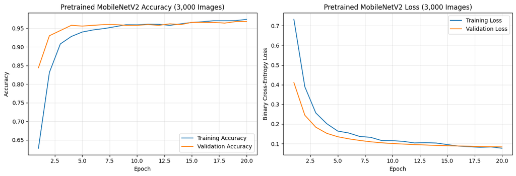

```python
# ============================================================
# AML Assignment 2 - Step 27: MobileNetV2 Graphs (3,000 Images)
# ============================================================

# Retrieve the training history
AML_TRANSFER_HISTORY_3000 = AML_HISTORY_PRETRAINED_3000.history

AML_TRANSFER_EPOCHS_3000 = range(
    1,
    len(AML_TRANSFER_HISTORY_3000["loss"]) + 1
)

# Create training accuracy and loss graphs
fig, axes = plt.subplots(1, 2, figsize=(13, 4.5))

# Graph 1: Accuracy
axes[0].plot(
    AML_TRANSFER_EPOCHS_3000,
    AML_TRANSFER_HISTORY_3000["accuracy"],
    label="Training Accuracy"
)

axes[0].plot(
    AML_TRANSFER_EPOCHS_3000,
    AML_TRANSFER_HISTORY_3000["val_accuracy"],
    label="Validation Accuracy"
)

axes[0].set_title("Pretrained MobileNetV2 Accuracy (3,000 Images)")
axes[0].set_xlabel("Epoch")
axes[0].set_ylabel("Accuracy")
axes[0].legend()
axes[0].grid(alpha=0.3)

# Graph 2: Loss
axes[1].plot(
    AML_TRANSFER_EPOCHS_3000,
    AML_TRANSFER_HISTORY_3000["loss"],
    label="Training Loss"
)

axes[1].plot(
    AML_TRANSFER_EPOCHS_3000,
    AML_TRANSFER_HISTORY_3000["val_loss"],
    label="Validation Loss"
)

axes[1].set_title("Pretrained MobileNetV2 Loss (3,000 Images)")
axes[1].set_xlabel("Epoch")
axes[1].set_ylabel("Binary Cross-Entropy Loss")
axes[1].legend()
axes[1].grid(alpha=0.3)

plt.tight_layout()
plt.show()
```

### 8.9 Interpretation of Pretrained MobileNetV2 Training Graphs with 3,000 Images

The accuracy graph shows that the pretrained MobileNetV2 model improved steadily during training with 3,000 images. Training accuracy increased from 62.77% to 97.40%, while validation accuracy improved from 84.40% to 96.80%.

The loss graph also shows a consistent decrease in training and validation loss. Training loss decreased from 0.7325 to 0.0765, while validation loss decreased from 0.4108 to 0.0832.

The training and validation results remained relatively close toward the end of training, suggesting that severe overfitting was not evident. Validation loss continued improving through the final epoch, so early stopping was not triggered.

The model achieved 96.00% accuracy on the independent test dataset, compared with 95.40% for the pretrained model using 1,000 images. This suggests that increasing the training dataset provided a modest additional benefit.

Overall, the graphs demonstrate that the pretrained model learned effectively and maintained strong validation performance when the training dataset was increased.

### 8.10 Pretrained MobileNetV2 Using 6,000 Training Images

For the final experiment, I increased the training dataset to 6,000 images, consisting of 3,000 cat images and 3,000 dog images.

I used the same pretrained MobileNetV2 architecture, ImageNet weights, preprocessing, and training configuration as in the previous transfer-learning experiments. A fresh model was initialized to ensure that the results reflected the effect of training dataset size rather than continued training from an earlier experiment.

The validation and test datasets remained fixed at 500 images each to maintain a consistent comparison across all six experiments.

The purpose of this experiment is to investigate whether increasing the training dataset from 3,000 to 6,000 images produces further improvements in classification accuracy and generalization.

```python
# ============================================================
# AML Assignment 2 - Step 28: Train MobileNetV2 (6,000 Images)
# ============================================================

# Prepare the 6,000-image training dataset
AML_PRETRAINED_TRAIN_6000 = aml_create_dataset(
    AML_TRAIN_SPLITS[6000],
    shuffle=True
)

# Build a fresh pretrained model
AML_PRETRAINED_MODEL_6000 = aml_build_pretrained_cnn()

# Configure early stopping
AML_PRETRAINED_STOPPING_6000 = keras.callbacks.EarlyStopping(
    monitor="val_loss",
    patience=5,
    restore_best_weights=True
)

# Train MobileNetV2 using 6,000 images
AML_HISTORY_PRETRAINED_6000 = AML_PRETRAINED_MODEL_6000.fit(
    AML_PRETRAINED_TRAIN_6000,
    validation_data=AML_VALIDATION_DATASET,
    epochs=20,
    callbacks=[AML_PRETRAINED_STOPPING_6000],
    verbose=1
)

print("\nPretrained MobileNetV2 (6,000 images) training completed!")
print(
    "Epochs completed:",
    len(AML_HISTORY_PRETRAINED_6000.history["loss"])
)
```

```
188/188 ━━━━━━━━━━━━━━━━━━━━ 45s 196ms/step - accuracy: 0.6903 - loss: 0.6149 - val_accuracy: 0.9300 - val_loss: 0.2569
188/188 ━━━━━━━━━━━━━━━━━━━━ 26s 140ms/step - accuracy: 0.9045 - loss: 0.2547 - val_accuracy: 0.9440 - val_loss: 0.1577
188/188 ━━━━━━━━━━━━━━━━━━━━ 42s 145ms/step - accuracy: 0.9367 - loss: 0.1757 - val_accuracy: 0.9460 - val_loss: 0.1288
188/188 ━━━━━━━━━━━━━━━━━━━━ 27s 142ms/step - accuracy: 0.9468 - loss: 0.1509 - val_accuracy: 0.9500 - val_loss: 0.1140
188/188 ━━━━━━━━━━━━━━━━━━━━ 27s 143ms/step - accuracy: 0.9548 - loss: 0.1270 - val_accuracy: 0.9540 - val_loss: 0.1053
188/188 ━━━━━━━━━━━━━━━━━━━━ 41s 144ms/step - accuracy: 0.9568 - loss: 0.1182 - val_accuracy: 0.9600 - val_loss: 0.0994
188/188 ━━━━━━━━━━━━━━━━━━━━ 26s 139ms/step - accuracy: 0.9632 - loss: 0.1034 - val_accuracy: 0.9600 - val_loss: 0.0954
188/188 ━━━━━━━━━━━━━━━━━━━━ 42s 143ms/step - accuracy: 0.9640 - loss: 0.1009 - val_accuracy: 0.9580 - val_loss: 0.0923
188/188 ━━━━━━━━━━━━━━━━━━━━ 40s 139ms/step - accuracy: 0.9635 - loss: 0.1010 - val_accuracy: 0.9600 - val_loss: 0.0894
188/188 ━━━━━━━━━━━━━━━━━━━━ 41s 142ms/step - accuracy: 0.9647 - loss: 0.0937 - val_accuracy: 0.9620 - val_loss: 0.0872
188/188 ━━━━━━━━━━━━━━━━━━━━ 27s 142ms/step - accuracy: 0.9673 - loss: 0.0868 - val_accuracy: 0.9640 - val_loss: 0.0871
188/188 ━━━━━━━━━━━━━━━━━━━━ 41s 140ms/step - accuracy: 0.9678 - loss: 0.0876 - val_accuracy: 0.9660 - val_loss: 0.0854
188/188 ━━━━━━━━━━━━━━━━━━━━ 41s 142ms/step - accuracy: 0.9682 - loss: 0.0852 - val_accuracy: 0.9660 - val_loss: 0.0840
188/188 ━━━━━━━━━━━━━━━━━━━━ 27s 142ms/step - accuracy: 0.9700 - loss: 0.0836 - val_accuracy: 0.9680 - val_loss: 0.0837
188/188 ━━━━━━━━━━━━━━━━━━━━ 27s 143ms/step - accuracy: 0.9712 - loss: 0.0787 - val_accuracy: 0.9680 - val_loss: 0.0829
188/188 ━━━━━━━━━━━━━━━━━━━━ 27s 144ms/step - accuracy: 0.9732 - loss: 0.0744 - val_accuracy: 0.9680 - val_loss: 0.0825
188/188 ━━━━━━━━━━━━━━━━━━━━ 27s 145ms/step - accuracy: 0.9728 - loss: 0.0772 - val_accuracy: 0.9680 - val_loss: 0.0819
188/188 ━━━━━━━━━━━━━━━━━━━━ 27s 142ms/step - accuracy: 0.9683 - loss: 0.0777 - val_accuracy: 0.9700 - val_loss: 0.0799
188/188 ━━━━━━━━━━━━━━━━━━━━ 41s 141ms/step - accuracy: 0.9742 - loss: 0.0711 - val_accuracy: 0.9700 - val_loss: 0.0798
188/188 ━━━━━━━━━━━━━━━━━━━━ 27s 145ms/step - accuracy: 0.9718 - loss: 0.0701 - val_accuracy: 0.9700 - val_loss: 0.0785

Pretrained MobileNetV2 (6,000 images) training completed!
Epochs completed: 20
```

### 8.11 Interpretation of Pretrained MobileNetV2 Training with 6,000 Images

The final pretrained MobileNetV2 experiment used 6,000 training images and completed all 20 epochs. Training accuracy increased from 69.03% in the first epoch to 97.18% in the final epoch. Validation accuracy also improved, increasing from 93.00% to 97.00%.

Training loss decreased from 0.6149 to 0.0701, while validation loss decreased from 0.2569 to 0.0785. These results indicate that the model learned effectively and continued improving throughout training.

The final training and validation accuracies were very close, suggesting that severe overfitting was not evident. Validation loss continued decreasing through the final epoch, so early stopping was not activated.

Compared with the pretrained models using 1,000 and 3,000 training images, the 6,000-image model achieved the highest final validation accuracy and lowest validation loss. However, the improvement from 3,000 to 6,000 images was smaller than the improvement from 1,000 to 3,000 images.

This suggests that additional training images continued to benefit the pretrained model, but the gains became smaller as performance approached a high accuracy level. The next step is to evaluate the model on the independent test dataset.

```python
# ============================================================
# AML Assignment 2 - Step 29: Evaluate MobileNetV2 (6,000)
# ============================================================

# Evaluate the final pretrained CNN
AML_TEST_LOSS_PRETRAINED_6000, AML_TEST_ACC_PRETRAINED_6000 = (
    AML_PRETRAINED_MODEL_6000.evaluate(
        AML_TEST_DATASET,
        verbose=0
    )
)

# Save the sixth experiment's results
AML_EXPERIMENT_RESULTS.append({
    "Model": "Pretrained MobileNetV2",
    "Training Images": 6000,
    "Test Accuracy": AML_TEST_ACC_PRETRAINED_6000,
    "Test Loss": AML_TEST_LOSS_PRETRAINED_6000
})

# Compare with the scratch CNN using 6,000 images
AML_TRANSFER_GAIN_6000 = (
    AML_TEST_ACC_PRETRAINED_6000 - AML_TEST_ACC_SCRATCH_6000
) * 100

# Compare with the pretrained CNN using 3,000 images
AML_TRANSFER_SIZE_GAIN_6000 = (
    AML_TEST_ACC_PRETRAINED_6000 - AML_TEST_ACC_PRETRAINED_3000
) * 100

print("QUESTION 4 - PRETRAINED MODEL (6,000 IMAGES)")
print(f"Test accuracy: {AML_TEST_ACC_PRETRAINED_6000 * 100:.2f}%")
print(f"Test loss: {AML_TEST_LOSS_PRETRAINED_6000:.4f}")

print(
    f"\nImprovement over scratch CNN (6,000 images): "
    f"{AML_TRANSFER_GAIN_6000:+.2f} percentage points"
)

print(
    f"Change from pretrained model (3,000 images): "
    f"{AML_TRANSFER_SIZE_GAIN_6000:+.2f} percentage points"
)
```

```
QUESTION 4 - PRETRAINED MODEL (6,000 IMAGES)
Test accuracy: 96.80%
Test loss: 0.0827

Improvement over scratch CNN (6,000 images): +21.80 percentage points
Change from pretrained model (3,000 images): +0.80 percentage points
```

### 8.12 Interpretation of Pretrained MobileNetV2 Test Performance with 6,000 Images

The pretrained MobileNetV2 model trained using 6,000 images achieved a test accuracy of 96.80% and a test loss of 0.0827. This means the model correctly classified 484 out of 500 unseen test images.

In comparison, the CNN trained from scratch using 6,000 images achieved a test accuracy of 75.00%. Therefore, the pretrained model performed 21.80 percentage points better, demonstrating the effectiveness of transfer learning for this image classification task.

Compared with the pretrained MobileNetV2 model using 3,000 images, test accuracy increased from 96.00% to 96.80%, representing an improvement of 0.80 percentage points. Test loss also decreased from 0.0982 to 0.0827.

Across the three pretrained experiments, test accuracy increased from 95.40% with 1,000 images to 96.00% with 3,000 images and 96.80% with 6,000 images.

These results suggest that increasing the training dataset continued to improve classification performance. However, the improvements were relatively small compared with the much larger gains observed when increasing the training size for the CNN trained from scratch.

Overall, the pretrained MobileNetV2 model using 6,000 images achieved the highest test accuracy among the six experiments.

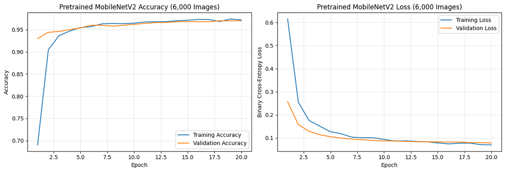

```python
# ============================================================
# AML Assignment 2 - Step 30: MobileNetV2 Graphs (6,000 Images)
# ============================================================

# Retrieve training history for the final pretrained model
AML_TRANSFER_HISTORY_6000 = AML_HISTORY_PRETRAINED_6000.history

AML_TRANSFER_EPOCHS_6000 = range(
    1,
    len(AML_TRANSFER_HISTORY_6000["loss"]) + 1
)

# Create accuracy and loss graphs
fig, axes = plt.subplots(1, 2, figsize=(13, 4.5))

# Graph 1: Training and validation accuracy
axes[0].plot(
    AML_TRANSFER_EPOCHS_6000,
    AML_TRANSFER_HISTORY_6000["accuracy"],
    label="Training Accuracy"
)

axes[0].plot(
    AML_TRANSFER_EPOCHS_6000,
    AML_TRANSFER_HISTORY_6000["val_accuracy"],
    label="Validation Accuracy"
)

axes[0].set_title("Pretrained MobileNetV2 Accuracy (6,000 Images)")
axes[0].set_xlabel("Epoch")
axes[0].set_ylabel("Accuracy")
axes[0].legend()
axes[0].grid(alpha=0.3)

# Graph 2: Training and validation loss
axes[1].plot(
    AML_TRANSFER_EPOCHS_6000,
    AML_TRANSFER_HISTORY_6000["loss"],
    label="Training Loss"
)

axes[1].plot(
    AML_TRANSFER_EPOCHS_6000,
    AML_TRANSFER_HISTORY_6000["val_loss"],
    label="Validation Loss"
)

axes[1].set_title("Pretrained MobileNetV2 Loss (6,000 Images)")
axes[1].set_xlabel("Epoch")
axes[1].set_ylabel("Binary Cross-Entropy Loss")
axes[1].legend()
axes[1].grid(alpha=0.3)

plt.tight_layout()
plt.show()
```

### 8.13 Interpretation of Pretrained MobileNetV2 Training Graphs with 6,000 Images

The training graphs for the pretrained MobileNetV2 model using 6,000 images show consistent improvements in classification performance. Training accuracy increased from 69.03% in the first epoch to 97.18% in the final epoch, while validation accuracy increased from 93.00% to 97.00%.

The loss graph shows a similar improvement. Training loss decreased from 0.6149 to 0.0701, and validation loss decreased from 0.2569 to 0.0785.

The training and validation results remained close during the later epochs, suggesting that severe overfitting was not evident. Validation loss continued decreasing through the final epoch, so early stopping was not activated.

The model also achieved 96.80% accuracy on the independent test dataset, which was the highest test accuracy among all six experiments.

Overall, these graphs suggest that pretrained MobileNetV2 generalized well to unseen images and benefited from the larger training dataset. However, the improvement from increasing the training size was relatively small because the pretrained model had already achieved strong performance with fewer images.

## 9. Final Comparison of All Six CNN Experiments

This section compares the performance of the three CNN models trained from scratch and the three pretrained MobileNetV2 models.

All experiments used the same 500 validation images and 500 test images. Training dataset sizes were 1,000, 3,000, and 6,000 images for both architectures.

The comparison focuses on test accuracy and test loss to examine how training dataset size and the use of pretrained visual features influence classification performance.

```python
# ============================================================
# AML Assignment 2 - Step 31: Final Six-Model Comparison Table
# ============================================================

# Convert the saved experiment results into a DataFrame
AML_FINAL_COMPARISON = pd.DataFrame(AML_EXPERIMENT_RESULTS)

# Arrange results by architecture and training dataset size
AML_FINAL_COMPARISON = AML_FINAL_COMPARISON.sort_values(
    by=["Model", "Training Images"]
).reset_index(drop=True)

# Display accuracy as a percentage for easier interpretation
AML_FINAL_COMPARISON["Test Accuracy (%)"] = (
    AML_FINAL_COMPARISON["Test Accuracy"] * 100
).round(2)

# Display test loss to four decimal places
AML_FINAL_COMPARISON["Test Loss"] = (
    AML_FINAL_COMPARISON["Test Loss"]
).round(4)

# Select the columns for the final report
AML_FINAL_REPORT_TABLE = AML_FINAL_COMPARISON[
    ["Model", "Training Images", "Test Accuracy (%)", "Test Loss"]
]

print("FINAL COMPARISON OF ALL SIX CNN EXPERIMENTS")
print("-" * 60)

display(AML_FINAL_REPORT_TABLE)
```

```
FINAL COMPARISON OF ALL SIX CNN EXPERIMENTS
------------------------------------------------------------
```

|  | Model | Training Images | Test Accuracy (%) | Test Loss |
| --- | --- | --- | --- | --- |
| 0 | Pretrained MobileNetV2 | 1000 | 95.4 | 0.1244 |
| 1 | Pretrained MobileNetV2 | 3000 | 96.0 | 0.0982 |
| 2 | Pretrained MobileNetV2 | 6000 | 96.8 | 0.0827 |
| 3 | Scratch CNN | 1000 | 61.8 | 0.6696 |
| 4 | Scratch CNN | 3000 | 72.0 | 0.5575 |
| 5 | Scratch CNN | 6000 | 75.0 | 0.5169 |

### 9.1 Interpretation of the Final Comparison Table

The final comparison table summarizes the performance of six CNN experiments using three different training dataset sizes and two model architectures.

For the CNN trained from scratch, test accuracy increased from 61.80% with 1,000 images to 72.00% with 3,000 images and 75.00% with 6,000 images. This represents an overall improvement of 13.20 percentage points. Test loss also decreased as the training dataset increased.

The pretrained MobileNetV2 models achieved considerably higher test accuracy at every training size. Test accuracy increased from 95.40% with 1,000 images to 96.00% with 3,000 images and 96.80% with 6,000 images. The overall improvement was 1.40 percentage points.

The results suggest that the scratch CNN benefited more from increasing the training dataset because it needed to learn visual features directly from the available images. In contrast, MobileNetV2 already contained useful visual features learned during ImageNet pretraining.

The pretrained MobileNetV2 model using 6,000 training images achieved the highest test accuracy of 96.80% and the lowest test loss of 0.0827.

Overall, these experiments demonstrate that both training dataset size and model architecture influence classification performance. Transfer learning provided a particularly large advantage when fewer training images were available.

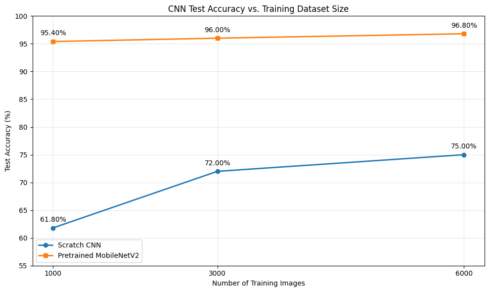

```python
# ============================================================
# AML Assignment 2 - Step 32: Final Accuracy Comparison Graph
# ============================================================

# Select the results for each model architecture
AML_GRAPH_SCRATCH = AML_FINAL_REPORT_TABLE[
    AML_FINAL_REPORT_TABLE["Model"] == "Scratch CNN"
].sort_values("Training Images")

AML_GRAPH_PRETRAINED = AML_FINAL_REPORT_TABLE[
    AML_FINAL_REPORT_TABLE["Model"] == "Pretrained MobileNetV2"
].sort_values("Training Images")

# Create a comparison graph
plt.figure(figsize=(10, 6))

# Plot scratch CNN performance
plt.plot(
    AML_GRAPH_SCRATCH["Training Images"],
    AML_GRAPH_SCRATCH["Test Accuracy (%)"],
    marker="o",
    linewidth=2,
    label="Scratch CNN"
)

# Plot pretrained MobileNetV2 performance
plt.plot(
    AML_GRAPH_PRETRAINED["Training Images"],
    AML_GRAPH_PRETRAINED["Test Accuracy (%)"],
    marker="s",
    linewidth=2,
    label="Pretrained MobileNetV2"
)

# Add accuracy labels to each data point
for aml_graph_data in [AML_GRAPH_SCRATCH, AML_GRAPH_PRETRAINED]:
    for _, aml_graph_row in aml_graph_data.iterrows():
        plt.annotate(
            f'{aml_graph_row["Test Accuracy (%)"]:.2f}%',
            (
                aml_graph_row["Training Images"],
                aml_graph_row["Test Accuracy (%)"]
            ),
            textcoords="offset points",
            xytext=(0, 9),
            ha="center"
        )

# Format the graph
plt.title("CNN Test Accuracy vs. Training Dataset Size")
plt.xlabel("Number of Training Images")
plt.ylabel("Test Accuracy (%)")
plt.xticks([1000, 3000, 6000])
plt.ylim(55, 100)
plt.grid(alpha=0.3)
plt.legend()
plt.tight_layout()

plt.show()
```

## 10. Discussion of Experimental Results

### 10.1 Effect of Training Dataset Size

The experiments showed that increasing the number of training images improved test accuracy for both CNN architectures.

For the CNN trained from scratch, accuracy increased from 61.80% with 1,000 images to 75.00% with 6,000 images. This improvement of 13.20 percentage points suggests that the scratch CNN depended strongly on the amount of training data available.

The pretrained MobileNetV2 model also improved as the dataset increased, but the difference was smaller. Its test accuracy increased from 95.40% to 96.80%, an improvement of 1.40 percentage points.

I found this difference interesting because it shows that adding more training images does not benefit every model equally. The scratch CNN had more to learn from the dataset, while MobileNetV2 could already recognize useful visual patterns through its pretrained feature-extraction layers.

### 10.2 Effect of CNN Architecture

The choice of CNN architecture had a substantial effect on classification performance.

The scratch CNN learned its visual features directly from the cat and dog images. Although its accuracy improved with additional training data, it did not match the performance of pretrained MobileNetV2.

MobileNetV2 used visual features learned from ImageNet and required training only a new classification layer. This approach produced substantially better results, even with the smallest training dataset.

With 1,000 images, MobileNetV2 achieved 95.40% test accuracy compared with 61.80% for the scratch CNN. The difference of 33.60 percentage points was the largest improvement between the two architectures.

These findings suggest that transfer learning can be especially useful when the available training dataset is limited.

### 10.3 Overfitting and Generalization

To reduce overfitting, I used data augmentation, dropout, and early stopping during the experiments. The scratch CNN also used a relatively compact architecture with global average pooling.

The pretrained MobileNetV2 models showed strong validation and test performance. Their training and validation accuracy values were close during the later epochs, suggesting that severe overfitting was not evident.

The scratch CNN models achieved lower accuracy, particularly when trained with 1,000 images. Their performance improved as additional training examples became available.

Using fixed validation and test datasets helped maintain a consistent basis for comparing the experiments.

### 10.4 Limitations

There are several limitations to consider when interpreting these results.

First, the experiments focused only on binary classification of cats and dogs. The findings may not apply directly to more complex image classification problems.

Second, the models were evaluated using a fixed test dataset of 500 images. Although this provided a consistent comparison, results could vary with a different test sample.

Third, each model configuration was trained once. Repeating the experiments with different random seeds would provide a more reliable estimate of performance variability.

Finally, the pretrained MobileNetV2 feature extractor remained frozen. Fine-tuning some of its layers might improve performance further, but this was outside the scope of the experiments.

## 11. Final Conclusion

This assignment investigated how training dataset size and CNN architecture affect image classification performance.

I developed and evaluated three CNN models trained from scratch using 1,000, 3,000, and 6,000 training images. I then repeated the experiments using pretrained MobileNetV2 with the same training dataset sizes.

The results showed that increasing the training dataset improved test accuracy for both architectures. However, the improvement was much larger for the scratch CNN, whose accuracy increased from 61.80% to 75.00%.

Pretrained MobileNetV2 consistently outperformed the scratch CNN at every training size. Its test accuracy ranged from 95.40% to 96.80%, demonstrating the benefit of reusing previously learned visual features.

The best-performing model was pretrained MobileNetV2 trained with 6,000 images, achieving **96.80% test accuracy and 0.0827 test loss**.

Overall, the experiments demonstrate that increasing training data can improve CNN performance, but model architecture and transfer learning can have an even greater impact. For this cat-versus-dog classification task, pretrained MobileNetV2 provided the strongest results while requiring relatively few trainable parameters.

## 12. References

1. **Kaggle Dataset:** Bhavik Jikadara. *Dog and Cat Classification Dataset*. Kaggle. https://www.kaggle.com/datasets/bhavikjikadara/dog-and-cat-classification-dataset
2. **TensorFlow/Keras:** TensorFlow. *Keras API Documentation*. https://www.tensorflow.org/api_docs/python/tf/keras
3. **MobileNetV2 Architecture:** Sandler, M., Howard, A., Zhu, M., Zhmoginov, A., & Chen, L.-C. (2018). *MobileNetV2: Inverted Residuals and Linear Bottlenecks*. Proceedings of the IEEE/CVF Conference on Computer Vision and Pattern Recognition. https://arxiv.org/abs/1801.04381
4. **Transfer Learning:** TensorFlow. *Transfer Learning and Fine-Tuning*. https://www.tensorflow.org/tutorials/images/transfer_learning

### Reproducibility Note

All experiments used a fixed random seed of 42, balanced cat and dog training subsets, and the same validation and test image splits. The CNN models were trained independently for each dataset size.

The scratch CNN experiments used image augmentation, dropout, and early stopping. The pretrained MobileNetV2 experiments used frozen ImageNet feature-extraction layers and newly initialized binary classification heads.

The experiments were conducted using Python, TensorFlow/Keras, and Google Colab.